# Basic facts and notions of logic and set theory

2020-04-11 18:49:34

```r
library(tidyverse)
library(kableExtra)
library(tidyquant)
library(knitr)
library(latex2exp)
library(ggforce)
```

# 1 Logic and set theory

This section is based on (Mendelson 2008, Chapter 1, pp 1-52)

This is a very brief introduction to the basic concepts and terminology of mathematical logic and set theory

For another introduction to set theory see (Halmos 1974) and for an extensive survey of the set theory see (Jech 2003)

For another introduction to mathematical logic see (Smullyan 2014) and for an extensive survey of mathematical logic see (Bilaniuk 2009)

## 1.1 Logical connectives

### 1.1.1 Conjuction

Given sentences $A$ and $B$, we may form a new sentence $A \text{ and } B$, which we shall write $A \land B$

The relation between the new sentence $A \land B$ and the component sentences $A,B$ can be made clear by a **truth table**:

```r
tibble(`$A$` = c("T", "F", "T", "F"),
       `$B$` = c("T", "T", "F", "F"),
       `$A \\land B$` = c("T", "F", "F", "F")) %>%
    kable(format = "html", escape = FALSE, align = "c") %>%
    kable_styling(full_width = FALSE, bootstrap_options = "bordered")
```

| $A$ | $B$ | $A \land B$ |
| --- | --- | --- |
| T | T | T |
| F | T | F |
| T | F | F |
| F | F | F |

In this table, as in all tables to follow, T stands for **True** and F for **False**

### 1.1.2 Negation

If $A$ is a sentence, the $\text{not } A$ is also a sentence, which we shall denote $\neg A$

$\neg A$ is called the **negation** of $A$

The corresponding **truth table** is:

```r
tibble(`$A$` = c("T", "F"),
       `$\\neg A$` = c("F", "T")) %>%
    kable(format = "html", escape = FALSE, align = "c") %>%
    kable_styling(full_width = FALSE, bootstrap_options = "bordered")
```

| $A$ | $\neg A$ |
| --- | --- |
| T | F |
| F | T |

### 1.1.3 Disjuction

Given sentences $A$ and $B$, we may form a new sentence $A \text{ or } B$, which we shall write $A \lor B$

$\lor$ is understood in the **inclusive sense**, namely, $A \lor B$ is true when $A$ is true or $B$ is true or both

The corresponding **true table** is

```r
tibble(`$A$` = c("T", "F", "T", "F"),
       `$B$` = c("T", "T", "F", "F"),
       `$A \\lor B$` = c("T", "T", "T", "F")) %>%
    kable(format = "html", escape = FALSE, align = "c") %>%
    kable_styling(full_width = FALSE, bootstrap_options = "bordered")
```

| $A$ | $B$ | $A \lor B$ |
| --- | --- | --- |
| T | T | T |
| F | T | T |
| T | F | T |
| F | F | F |

If a set of formulas take the same truth values we said that these formulas are **equivalent**. For example:

- $A \lor A$ and $A$
  - When $A$ is T, so is $A \lor A$, and viceversa
- $A \land A$ and $A$
  - $A$ is T if and only if $A \land A$ is T
- $A \lor (B \land A)$ and $A$
  - When $A$ is T, so is $A \lor (B \land A)$. If $A$ is F, then $A \lor (B \land A)$ is F. Using a **true table** we can see that:

```r
tibble(`$A$` = c("T", "F", "T", "F"),
       `$B$` = c("T", "T", "F", "F"),
       `$A \\land B$` = c("T", "F", "F", "F"),
       `$A \\lor (A \\land B)$` = c("T", "F", "T", "F")) %>%
    kable(format = "html", escape = FALSE, align = "c") %>%
    kable_styling(full_width = FALSE, bootstrap_options = "bordered")
```

| $A$ | $B$ | $A \land B$ | $A \lor (A \land B)$ |
| --- | --- | --- | --- |
| T | T | T | T |
| F | T | F | F |
| T | F | F | T |
| F | F | F | F |

## 1.2 Logical connectives exercises and solutions

1. Write the following English sentences in terms of our new notation. Use letters $A, B, C,...$ to stand for the basic sentences
   1. I will go to the movies or to the beach
      - $A = \text{I will go to the movies}$
      - $B = \text{I will go to the beach}$
      - $A \lor B = \text{I will go to the movies or to the beach}$
   2. Peter is handsome but Paul is not
      - $A = \text{Peter is handsome}$
      - $B = \text{Paul is handsome}$
      - $A \land \neg B = \text{Peter is handsome but Paul is not}$
   3. Either $x$ has a square root or $x$ is not positive
      - $A = x \text{ has a square root}$
      - $B = x \text{ is positive}$
      - $A \lor \neg B = \text{Either } x \text{ has a square root or } x \text{ is not positive}$
   4. It is not the case that $x$ is both positive and negative
      - $A = x \text{ is positive}$
      - $B = x \text{ is negative}$
      - $\neg (A \land B) = \text{It is not the case that } x \text{ is both positive and negative}$
   5. Neither John not James is here
      - $A = \text{John is here}$
      - $B = \text{James is here}$
      - $\neg (A \land B) = \text{Neither John not James is here}$
2. Render the following into idiomatic English
   1. $x > 2 \lor x < 2$
      - $x$ is greater than or less than $2$
   2. $\neg (y \text{ is rational } \lor y \text{ is trascendental})$
      - Neither $y$ is rational or transcendental
   3. $e > 2 \land e < 3$
      - $e$ is greater than $2$ and less than $3$
   4. $e > 2 \land e \ngtr 3$
      - $e$ is greater than $2$ but not greater than $3$
3. Show that the following pairs of formulas always take the same truth values, and, therefore, are, in a certain sense, equivalent:
   1. $\neg (A \lor B)$ and $(\neg A) \land (\neg B)$

```r
tibble(`$A$` = c("T", "F", "T", "F"),
       `$B$` = c("T", "T", "F", "F"),
       `$A \\lor B$` = c("T", "T", "T", "F"),
       `$\\neg (A \\lor B)$` = c("F", "F", "F", "T"),
       `$(\\neg A)$` = c("F", "T", "F", "T"),
       `$(\\neg B)$` = c("F", "F", "T", "T"),
       `$(\\neg A) \\land (\\neg B)$` = c("F", "F", "F", "T")) %>%
    kable(format = "html", escape = FALSE, align = "c") %>%
    kable_styling(full_width = FALSE, bootstrap_options = "bordered") %>%
    column_spec(column = c(4, 7), background = palette_light()[[7]])
```

| $A$ | $B$ | $A \lor B$ | $\neg (A \lor B)$ | $(\neg A)$ | $(\neg B)$ | $(\neg A) \land (\neg B)$ |
| --- | --- | --- | --- | --- | --- | --- |
| T | T | T | F | F | F | F |
| F | T | T | F | T | F | F |
| T | F | T | F | F | T | F |
| F | F | F | T | T | T | T |

```
b. $\neg (A \land B)$ and $(\neg A) \lor (\neg B)$
```

```r
tibble(`$A$` = c("T", "F", "T", "F"),
       `$B$` = c("T", "T", "F", "F"),
       `$A \\land B$` = c("T", "F", "F", "F"),
       `$\\neg (A \\land B)$` = c("F", "T", "T", "T"),
       `$(\\neg A)$` = c("F", "T", "F", "T"),
       `$(\\neg B)$` = c("F", "F", "T", "T"),
       `$(\\neg A) \\lor (\\neg B)$` = c("F", "T", "T", "T")) %>%
    kable(format = "html", escape = FALSE, align = "c") %>%
    kable_styling(full_width = FALSE, bootstrap_options = "bordered") %>%
    column_spec(column = c(4, 7), background = palette_light()[[7]])
```

| $A$ | $B$ | $A \land B$ | $\neg (A \land B)$ | $(\neg A)$ | $(\neg B)$ | $(\neg A) \lor (\neg B)$ |
| --- | --- | --- | --- | --- | --- | --- |
| T | T | T | F | F | F | F |
| F | T | F | T | T | F | T |
| T | F | F | T | F | T | T |
| F | F | F | T | T | T | T |

```
c. $\neg \neg B$ and $B$
```

```r
tibble(`$B$` = c("T", "F"),
       `$\\neg B$` = c("F", "T"),
       `$\\neg \\neg B$` = c("T", "F")) %>%
    kable(format = "html", escape = FALSE, align = "c") %>%
    kable_styling(full_width = FALSE, bootstrap_options = "bordered") %>%
    column_spec(column = c(1, 3), background = palette_light()[[7]])
```

| $B$ | $\neg B$ | $\neg \neg B$ |
| --- | --- | --- |
| T | F | T |
| F | T | F |

```
d. $A \land (B \lor C)$ and $(A \land B) \lor (A \land C)$
```

```r
tibble(`$A$` = c("T", "T", "T", "T", "F", "F", "F", "F"),
       `$B$` = c("T", "T", "F", "F", "T", "T", "F", "F"),
       `$C$` = c("T", "F", "T", "F", "T", "F", "T", "F"),
       `$B \\lor C$` = c("T", "T", "T", "F", "T", "T", "T", "F"),
       `$A \\land (B \\lor C)$` = c("T", "T", "T", "F", "F", "F", "F", "F"),
       `$A \\land B$` = c("T", "T", "F", "F", "F", "F", "F", "F"),
       `$A \\land C$` = c("T", "F", "T", "F", "F", "F", "F", "F"),
       `$(A \\land B) \\lor (A \\land C)$` = c("T", "T", "T", "F", "F", "F", "F", "F")) %>%
    kable(format = "html", escape = FALSE, align = "c") %>%
    kable_styling(full_width = FALSE, bootstrap_options = "bordered") %>%
    column_spec(column = c(5, 8), background = palette_light()[[7]])
```

| $A$ | $B$ | $C$ | $B \lor C$ | $A \land (B \lor C)$ | $A \land B$ | $A \land C$ | $(A \land B) \lor (A \land C)$ |
| --- | --- | --- | --- | --- | --- | --- | --- |
| T | T | T | T | T | T | T | T |
| T | T | F | T | T | T | F | T |
| T | F | T | T | T | F | T | T |
| T | F | F | F | F | F | F | F |
| F | T | T | T | F | F | F | F |
| F | T | F | T | F | F | F | F |
| F | F | T | T | F | F | F | F |
| F | F | F | F | F | F | F | F |

```
e. $A \lor (B \land C)$ and $(A \lor B) \land (A \lor C)$
```

```r
tibble(`$A$` = c("T", "T", "T", "T", "F", "F", "F", "F"),
       `$B$` = c("T", "T", "F", "F", "T", "T", "F", "F"),
       `$C$` = c("T", "F", "T", "F", "T", "F", "T", "F"),
       `$B \\land C$` = c("T", "F", "F", "F", "T", "F", "F", "F"),
       `$A \\lor (B \\land C)$` = c("T", "T", "T", "T", "T", "F", "F", "F"),
       `$A \\lor B$` = c("T", "T", "T", "T", "T", "T", "F", "F"),
       `$A \\lor C$` = c("T", "T", "T", "T", "T", "F", "T", "F"),
       `$(A \\lor B) \\land (A \\lor C)$` = c("T", "T", "T", "T", "T", "F", "F", "F")) %>%
    kable(format = "html", escape = FALSE, align = "c") %>%
    kable_styling(full_width = FALSE, bootstrap_options = "bordered") %>%
    column_spec(column = c(5, 8), background = palette_light()[[7]])
```

| $A$ | $B$ | $C$ | $B \land C$ | $A \lor (B \land C)$ | $A \lor B$ | $A \lor C$ | $(A \lor B) \land (A \lor C)$ |
| --- | --- | --- | --- | --- | --- | --- | --- |
| T | T | T | T | T | T | T | T |
| T | T | F | F | T | T | T | T |
| T | F | T | F | T | T | T | T |
| T | F | F | F | T | T | T | T |
| F | T | T | T | T | T | T | T |
| F | T | F | F | F | T | F | F |
| F | F | T | F | F | F | T | F |
| F | F | F | F | F | F | F | F |

## 1.3 Conditionals

Given sentences $A$ and $B$, we may form a new sentence $\text{If } A \text{ then } B$, which we shall write $A \implies B$

$A \implies B$ is know as a **conditional**, with **antecedent** $A$ and **consequent** $B$

The corresponding **true table** is

```r
tibble(`$A$` = c("T", "F", "T", "F"),
       `$B$` = c("T", "T", "F", "F"),
       `$A \\implies B$` = c("T", "T", "F", "T")) %>%
    kable(format = "html", escape = FALSE, align = "c") %>%
    kable_styling(full_width = FALSE, bootstrap_options = "bordered")
```

| $A$ | $B$ | $A \implies B$ |
| --- | --- | --- |
| T | T | T |
| F | T | T |
| T | F | F |
| F | F | T |

There is one line of this table which is clear, the third. For, if $A$ is true and $B$ is false, then $\text{If } A \text{ then } B$ is obviously false

However, there is no obvious reason for the entries in the other three rows of the table on the basis of ordinary usage. In that sense, the truth table we have established for $\implies$ is an extension of ordinary usage

The above **true table** reflects the meaning that $\implies$ has in contemporary mathematical logic. Two peculiar properties of $\implies$ sometimes cause problem:

- If $A$ is false, then $A \implies B$ is true (no matter what $B$ is)
- If $B$ is true, then $A \implies B$ is true (no matter what $A$ is)

Aside from these peculiar properties of $\implies$ the 2 most important properties of $\implies$ are:

- When $A$ and $A \implies B$ are both true, the $B$ must be true
  - $\{ A, A \implies B \} \vDash B$ (Bilaniuk 2009, Chapter 2, Definition 2.4, p 10)
- In order to prove $A \implies B$, it suffices to assume $A$ true and then show that $B$ must also be true
  - $\{ A, A \implies B \} \vdash B$ (Bilaniuk 2009, Chapter 3, Definition 3.3, p 12)

### 1.3.1 Necessary and sufficient condition

The sentence $\text{The truth of } A \text{ is a necessary condition for the truth of } B$ means that, if $B$ is true, then $A$ also must be true, and, thus, should be translated as $B \implies A$. For example,

- $A$ is $x > 5$
- $B$ is $(x > 10)$
- A **necesary condition** for $B$ is $A$
  - For $B$ to be true it is necessary for $A$ to be true

The sentence $\text{The truth of } A \text{ is a sufficient condition for the truth of } B$ means that, if $A$ is true, $B$ also must be true, and, thus, should be translated as $A \implies B$. For example,

- $A$ is $(x = 2n + 1) \land n \in \mathbb{N} \land \mathbb{N} = \{1, 2, ... \}$
- $B$ is $(x^2 = 2m + 1) \land m \in \mathbb{N} \land \mathbb{N} = \{1, 2, ... \}$
- A **sufficient condition** for $A$ is $B$
  - For $A$ to be true it is sufficient for $B$ to be true
- For example, assume that $A \cap B \neq \emptyset$
  - **Sufficient condition** for $x \in A$: $x \in A \cap B$
  - **Necessary condition** for $x \in A \cap B$: $x \in A$
  - **Sufficient** and **necessary condition** for $x \in A \cap B$: $x \in A \land x \in B$

In summary a **necessary condition** is a condition that must be present in order for another condition to occur and a **sufficient condition** is a condition that will produce another condition

## 1.4 Conditionals exercises and solutions

1. Translate into our symbolism the following English sentences
1. If John is not sick and it is not raining, we shall go on a picnic
   - $A = \text{John is not sick}$
   - $B = \text{It is raining}$
   - $C = \text{We shall go on a picnic}$
   - $(A \land \neg B) \implies C = \text{If John is not sick and it is not raining, we shall go on a picnic}$
2. Sam goes to work only if the sun is not shinning
   - $A = \text{Sam goes to work}$
   - $B = \text{The sun is shinning}$
   - $\neg B \implies A = \text{Sam goes to work only if the sun is not shinning}$
3. A sufficient condition for $f$ to be continuous is that $f$ is differentiable
   - $A = f \text{ is a continuous function}$
   - $B = f \text{ is a differentiable function}$
   - $A \implies B = \text{A sufficient condition for } f \text{ to be continuous is that } f \text{ is differentiable}$
4. A necessary condition for $s$ to converge is that $s$ is bounded
   - $A = s \text{ converge}$
   - $B = s \text{ is bounded}$
   - $B \implies A = \text{A necessary condition for } s \text{ to converge is that } s \text{ is bounded}$
2. Show that the following sentences always have the same truth values and are, therefore, equivalent
   1. $A \implies B$
   2. $(\neg A) \lor B$
   3. $\neg (A \land (\neg B))$

```r
tibble(`$A$` = c("T", "F", "T", "F"),
       `$B$` = c("T", "T", "F", "F"),
       `$A \\implies B$` = c("T", "T", "F", "T"),
       `$\\neg A$` = c("F", "T", "F", "T"),
       `$(\\neg A) \\lor B$` = c("T", "T", "F", "T"),
       `$\\neg B$` = c("F", "F", "T", "T"),
       `$A \\land (\\neg B)$` = c("F", "F", "T", "F"),
       `$\\neg (A \\land (\\neg B))$` = c("T", "T", "F", "T")) %>%
    kable(format = "html", escape = FALSE, align = "c") %>%
    kable_styling(full_width = FALSE, bootstrap_options = "bordered") %>%
    column_spec(column = c(3, 5, 8), background = palette_light()[[7]])
```

| $A$ | $B$ | $A \implies B$ | $\neg A$ | $(\neg A) \lor B$ | $\neg B$ | $A \land (\neg B)$ | $\neg (A \land (\neg B))$ |
| --- | --- | --- | --- | --- | --- | --- | --- |
| T | T | T | F | T | F | F | T |
| F | T | T | T | T | F | F | T |
| T | F | F | F | F | T | T | F |
| F | F | T | T | T | T | F | T |

```r
tibble(`$C$` = c("T", "F", "T", "F"),
       `$D$` = c("T", "T", "F", "F"),
       `$C \\land D$` = c("T", "F", "F", "F"),
       `$(C \\land D) \\implies D$` = c("T", "F", "T", "T")) %>%
    kable(format = "html", escape = FALSE, align = "c") %>%
    kable_styling(full_width = FALSE, bootstrap_options = "bordered")
```

| $C$ | $D$ | $C \land D$ | $(C \land D) \implies D$ |
| --- | --- | --- | --- |
| T | T | T | T |
| F | T | F | F |
| T | F | F | T |
| F | F | F | T |

4. Show that the following pairs of sentences are equivalent, that is, always take the same truth values:
   1. $\neg (A \implies B)$ and $\neg (A \land (\neg B))$

```r
tibble(`$A$` = c("T", "F", "T", "F"),
       `$B$` = c("T", "T", "F", "F"),
       `$A \\implies B$` = c("T", "T", "F", "T"),
       `$\\neg (A \\implies B)$` = c("F", "F", "T", "F"),
       `$\\neg B$` = c("F", "F", "T", "T"),
       `$A \\land (\\neg B)$` = c("F", "F", "T", "F")) %>%
    kable(format = "html", escape = FALSE, align = "c") %>%
    kable_styling(full_width = FALSE, bootstrap_options = "bordered") %>%
    column_spec(column = c(4, 6), background = palette_light()[[7]])
```

| $A$ | $B$ | $A \implies B$ | $\neg (A \implies B)$ | $\neg B$ | $A \land (\neg B)$ |
| --- | --- | --- | --- | --- | --- |
| T | T | T | F | F | F |
| F | T | T | F | F | F |
| T | F | F | T | T | T |
| F | F | T | F | T | F |

```
b. $A \implies (B \implies C)$ and $(A \land B) \implies C$
```

```r
tibble(`$A$` = c("T", "T", "T", "T", "F", "F", "F", "F"),
       `$B$` = c("T", "T", "F", "F", "T", "T", "F", "F"),
       `$C$` = c("T", "F", "T", "F", "T", "F", "T", "F"),
       `$B \\implies C$` = c("T", "F", "T", "T", "T", "F", "T", "T"),
       `$A \\implies (B \\implies C)$` = c("T", "F", "T", "T", "T", "T", "T", "T"),
       `$A \\land B$` = c("T", "T", "F", "F", "F", "F", "F", "F"),
       `$(A \\land B) \\implies C$` = c("T", "F", "T", "T", "T", "T", "T", "T")) %>%
    kable(format = "html", escape = FALSE, align = "c") %>%
    kable_styling(full_width = FALSE, bootstrap_options = "bordered") %>%
    column_spec(column = c(5, 7), background = palette_light()[[7]])
```

| $A$ | $B$ | $C$ | $B \implies C$ | $A \implies (B \implies C)$ | $A \land B$ | $(A \land B) \implies C$ |
| --- | --- | --- | --- | --- | --- | --- |
| T | T | T | T | T | T | T |
| T | T | F | F | F | T | F |
| T | F | T | T | T | F | T |
| T | F | F | T | T | F | T |
| F | T | T | T | T | F | T |
| F | T | F | F | T | F | T |
| F | F | T | T | T | F | T |
| F | F | F | T | T | F | T |

[output not shown]

```r
tibble(`$A$` = c("T", "F", "T", "F"),
       `$B$` = c("T", "T", "F", "F"),
       `$A \\implies B$` = c("T", "T", "F", "T"),
       `$\\neg A$` = c("F", "T", "F", "T"),
       `$\\neg B$` = c("F", "F", "T", "T"),
       `$(\\neg B) \\implies (\\neg A)$` = c("T", "T", "F", "T")) %>%
    kable(format = "html", escape = FALSE, align = "c") %>%
    kable_styling(full_width = FALSE, bootstrap_options = "bordered")  %>%
    column_spec(column = c(3, 6), background = palette_light()[[7]])
```

| $A$ | $B$ | $A \implies B$ | $\neg A$ | $\neg B$ | $(\neg B) \implies (\neg A)$ |
| --- | --- | --- | --- | --- | --- |
| T | T | T | F | F | T |
| F | T | T | T | F | T |
| T | F | F | F | T | F |
| F | F | T | T | T | T |

5. *Reductio ad adsurdum*
   1. Show that if $\neg A \implies (B \land (\neg B))$ is true, then $A$ is true. This justifies proofs by *reductio ad adsurdum*
      - To prove $A$, show that $\neg A$ leads to a contradiction

```r
tibble(`$A$` = c("T", "F", "T", "F"),
       `$\\neg A$` = c("F", "T", "F", "T"),
       `$B \\land (\\neg B)$` = c("F", "F", "F", "F"),
       `$\\neg A \\implies (B \\land (\\neg B))$` = c("T", "F", "F", "F")
       ) %>%
    kable(format = "html", escape = FALSE, align = "c") %>%
    kable_styling(full_width = FALSE, bootstrap_options = "bordered")  %>%
    row_spec(row = 1, background = palette_light()[[7]])
```

| $A$ | $\neg A$ | $B \land (\neg B)$ | $\neg A \implies (B \land (\neg B))$ |
| --- | --- | --- | --- |
| T | F | F | T |
| F | T | F | F |
| T | F | F | F |
| F | T | F | F |

```
b. Prove by _reductio ad adsurdum_ that $A \implies A$ is always true
```

Assume that $\neg (A \implies A)$. This is equivalent to $A \land (\neg A)$ by exercise 4a. Therefore $\neg (A \implies A) \implies (A \land (\neg A))$ is true and we conclude by *reductio ad adsurdum* that $A \implies A$ is true

### 1.4.1 Making sense of the **truth table** for conditionals

#### 1.4.1.1 Possible **truth tables** for 2 binary variables

- There are 16 possible **truth tables** for two binary variables: $A, B$

```r
tibble(`$A$` = c("T", "F", "T", "F"),
       `$B$` = c("T", "T", "F", "F"),
       `$\\neg A$` = c("F", "T", "F", "T"),
       `$\\neg B$` = c("F", "F", "T", "T"),
       `$A \\land B$` = c("T", "F", "F", "F"),
       `$A \\lor B$` = c("T", "T", "T", "F"),
       `$A \\oplus B$` = c("F", "T", "T", "F"),
       `$A \\uparrow B$` = c("F", "T", "T", "T"),
       `$A \\downarrow B$` = c("F", "F", "F", "T"),
       `$A \\implies B$` = c("T", "T", "F", "T"),
       `$A \\Longleftarrow B$` = c("T", "F", "T", "T"),
       `$\\neg (A \\implies B)$` = c("F", "F", "T", "F"),
       `$\\neg (A \\Longleftarrow B)$` = c("F", "T", "F", "F"),
       `$A \\iff B$` = c("T", "F", "F", "T"),
       `$\\top$` = c("T", "T", "T", "T"),
       `$\\bot$` = c("F", "F", "F", "F")) %>%
    kable(format = "html", escape = FALSE, align = "c") %>%
    kable_styling(full_width = FALSE, bootstrap_options = "bordered") %>%
    row_spec(row = 3, background = palette_light()[[7]]) %>%
    column_spec(column = c(2, 3, 5, 9, 13, 14, 16), background = palette_light()[[7]])
```

| $A$ | $B$ | $\neg A$ | $\neg B$ | $A \land B$ | $A \lor B$ | $A \oplus B$ | $A \uparrow B$ | $A \downarrow B$ | $A \implies B$ | $A \Longleftarrow B$ | $\neg (A \implies B)$ | $\neg (A \Longleftarrow B)$ | $A \iff B$ | $\top$ | $\bot$ |
| --- | --- | --- | --- | --- | --- | --- | --- | --- | --- | --- | --- | --- | --- | --- | --- |
| T | T | F | F | T | T | F | F | F | T | T | F | F | T | T | F |
| F | T | T | F | F | T | T | T | F | T | F | F | T | F | T | F |
| T | F | F | T | F | T | T | T | F | F | T | T | F | F | T | F |
| F | F | T | T | F | F | F | T | T | T | T | F | F | T | T | F |

- Where
  - $A$ is the case of a **truth function** that only depends on the binary variable $A$
  - $B$ is the case of a **truth function** that only depends on the binary variable $B$
  - $\neg A$ is the negation of $A$ (also is a **truth function** that only depends on the binary variable $A$)
  - $\neg B$ is the negation of $B$ (also is a **truth function** that only depends on the binary variable $B$)
  - $A \land B$ is a conjunction
  - $A \lor B$ is a disjunction
  - $A \oplus B$ is a exclusive disjunction and known as **XOR**: $(A \lor B) \land \neg (A \land B)$
  - $A \uparrow B$ is known as **NAND**: $\neg (A \land B)$
  - $A \downarrow B$ is known as **NOR**: $\neg (A \lor B)$
  - $A \implies B$ is know as the material conditional: $\neg (A \land \neg B)$
  - $A \Longleftarrow B$ is know as the converse of material conditional: $\neg (B \land \neg A)$
  - $\neg (A \implies B)$ is the negation of the material implication
  - $\neg (A \Longleftarrow B)$ is the negation of the converse of the material implication
  - $A \iff B$ is a biconditional
  - $\top$ is a tautology
  - $\bot$ is a contradiction

#### 1.4.1.2 Alternative **truth tables** for $\implies$

- The columns colored in green from the above table are the alternative **truth tables** for $A \implies B$
  - This columns are cases where $A$ is true, $B$ is false and the value of the **truth table** is false
    - We discard $B$ and $\neg A$ because these tables only depend on one binary variable
    - We discard $\bot$ because is a contradiction
    - We discard $A \land B$, and $A \iff B$ becasue are logical connectives with a clear interpretation in mathematical logic
    - The remaining candidates are $A \downarrow B$ and $\neg (A \Longleftarrow B)$
      - The problem with this logical connectives as alternative candidates for $A \implies B$ is that when $A$ and $B$ are true the value of the **truth table** is false
- Therefore for 2 binary variables, we may conclude that $A \implies B$ doesn’t have other suitable alternatives assuming that we want
  - $A$ true, $B$ false and false for the value of the **truth table**
  - $A$ true, $B$ true and true for the value of the **truth table**

## 1.5 Biconditionals

Given sentences $A$ and $B$, we may form a new sentence $\text{If } A \text{ and only if } B$, which we shall write $A \iff B$

The corresponding **true table** is

```r
tibble(`$A$` = c("T", "F", "T", "F"),
       `$B$` = c("T", "T", "F", "F"),
       `$A \\iff B$` = c("T", "F", "F", "T")) %>%
    kable(format = "html", escape = FALSE, align = "c") %>%
    kable_styling(full_width = FALSE, bootstrap_options = "bordered")
```

| $A$ | $B$ | $A \iff B$ |
| --- | --- | --- |
| T | T | T |
| F | T | F |
| T | F | F |
| F | F | T |

## 1.6 Biconditionals exercises and solutions

1. Translate into our symbolism:
   1. A necessary and suficient condition for $s$ to be convergent is that it is cauchy convergent
      - $A = s \text{ is convergent}$
      - $B = s \text{ is cauchy convergent}$
      - $A \iff B = \text{A necessary and suficient condition for } s \text{ to be convergent is that it is cauchy convergent}$
   2. Horatio is happy if and only if the sun is shining and business is good
      - $A = \text{Horatio is happy}$
      - $B = \text{The sun is shining}$
      - $C = \text{Business is good}$
      - $A \iff (B \land C) = \text{Horatio is happy if and only if the sun is shining and business is good}$
   3. $f$ is differentiable when and only when it is continuous
      - $A = f \text{ is a differentiable function}$
      - $B = f \text{ is a continuous function}$
      - $A \iff B = f \text{ is differentiable when and only when it is continuous}$
2. Show that $A \iff B$ always has the same truth values as $(A \implies B) \land (B \implies A)$. Hence to prove $A \iff B$ it suffices to prove $A \implies B$ and $B \implies A$

```r
tibble(`$A$` = c("T", "F", "T", "F"),
       `$B$` = c("T", "T", "F", "F"),
       `$A \\Longrightarrow B$` = c("T", "T", "F", "T"),
       `$B \\Longrightarrow A$` = c("T", "F", "T", "T"),
       `$(A \\Longrightarrow B) \\land (B \\Longrightarrow A)$` = c("T", "F", "F", "T"),
       `$A \\iff B$` = c("T", "F", "F", "T")
       ) %>%
    kable(format = "html", escape = FALSE, align = "c") %>%
    kable_styling(full_width = FALSE, bootstrap_options = "bordered")  %>%
    column_spec(column = c(5, 6), background = palette_light()[[7]])
```

| $A$ | $B$ | $A \Longrightarrow B$ | $B \Longrightarrow A$ | $(A \Longrightarrow B) \land (B \Longrightarrow A)$ | $A \iff B$ |
| --- | --- | --- | --- | --- | --- |
| T | T | T | T | T | T |
| F | T | T | F | F | F |
| T | F | F | T | F | F |
| F | F | T | T | T | T |

3. Assume that $A \lor B$ is true. What, if anything, can be said of the truth table values of the following?
   1. $A$
      - Nothing because $A$ can be true or false
   2. $A \implies B$
      - Nothing because $A$ can be true and $B$ false or $B$ can be true
   3. $\neg A \implies B$
      - $\neg A \implies B$ is true because $B$ is true or $A$ is false and $B is false$
   4. $\neg ((\neg A) \land (\neg B))$
      - $\neg A \implies B$ is true because $\neg A$ is false and $\neg B$ is false or $\neg A$ and $\neg B$ have different truth values
   5. $(A \land C) \lor (B \land (\neg C))$
      - Nothing because $A$ and $B$ can have the same true values

```r
tibble(`$A$` = c("T", "F", "T"),
       `$B$` = c("T", "T", "F"),
       `$A \\lor B$` = c("T", "T", "T"),
       `$A \\implies B$` = c("T", "T", "F"),
       `$\\neg A \\implies B$` = c("T", "T", "T")) %>%
    kable(format = "html", escape = FALSE, align = "c") %>%
    kable_styling(full_width = FALSE, bootstrap_options = "bordered")
```

| $A$ | $B$ | $A \lor B$ | $A \implies B$ | $\neg A \implies B$ |
| --- | --- | --- | --- | --- |
| T | T | T | T | T |
| F | T | T | T | T |
| T | F | T | F | T |

```r
tibble(`$A$` = c("T", "T", "F", "F", "T", "T"),
       `$B$` = c("T", "T", "T", "T", "F", "F"),
       `$C$` = c("T", "F", "T", "F", "T", "F"),
       `$A \\land C$` = c("T", "F", "F", "F", "T", "F"),
       `$B \\land \\neg C$` = c("F", "T", "F", "T", "T", "F"),
       `$(A \\land C) \\lor (B \\land (\\neg C))$` = c("T", "T", "T", "T", "T", "F")) %>%
    kable(format = "html", escape = FALSE, align = "c") %>%
    kable_styling(full_width = FALSE, bootstrap_options = "bordered")
```

| $A$ | $B$ | $C$ | $A \land C$ | $B \land \neg C$ | $(A \land C) \lor (B \land (\neg C))$ |
| --- | --- | --- | --- | --- | --- |
| T | T | T | T | F | T |
| T | T | F | F | T | T |
| F | T | T | F | F | T |
| F | T | F | F | T | T |
| T | F | T | T | T | T |
| T | F | F | F | F | F |

4. Assume that $A \implies B$ is true. What, if anything, can be said of the truth values of the following?
   1. $B$
      - Nothing because $B$ can be true or false
   2. $A \lor B$
      - Nothing because $A$ and $B$ can have the same true values
   3. $(\neg A) \lor B$
      - $(\neg A) \lor B$ is true because $\neg A$ and $\neg B$ have different true values or $\neg A$ and $\neg B$ are false
   4. $B \implies A$
      - Nothing because $B$ is true and $A$ is false or $B$ is false or $A$ is true
   5. $(\neg B) \implies (\neg A)$
      - $(\neg B) \implies (\neg A)$ is true because it is not the case that $\neg B$ is true and $\neg A$ is false

```r
tibble(`$A$` = c("T", "F", "F"),
       `$B$` = c("T", "T", "F"),
       `$A \\implies B$` = c("T", "T", "T"),
       `$A \\lor B$` = c("T", "T", "F"),
       `$\\neg A \\lor B$` = c("T", "T", "T"),
       `$B \\implies A$` = c("T", "F", "T"),
       `$\\neg B \\implies \\neg A$` = c("T", "T", "T")) %>%
    kable(format = "html", escape = FALSE, align = "c") %>%
    kable_styling(full_width = FALSE, bootstrap_options = "bordered")
```

| $A$ | $B$ | $A \implies B$ | $A \lor B$ | $\neg A \lor B$ | $B \implies A$ | $\neg B \implies \neg A$ |
| --- | --- | --- | --- | --- | --- | --- |
| T | T | T | T | T | T | T |
| F | T | T | T | T | F | T |
| F | F | T | F | T | T | T |

5. Assume that $A$ is true, $B$ is false, and $C$ is true. What are the truth values of:
   1. $A \implies B$
      - False
   2. $B \implies C$
      - True
   3. $(A \lor \neg C) \lor B$
      - True
   4. $(A \iff C) \iff \neg B$
      - True
   5. $A \implies (B \implies A)$
      - True
6. For each of the following pairs of sentences show that they are equivalent, in the sense that they always take the same truth values
   1. $A \land (B \lor \neg A)$ and $A \land B$
      - $A \land (B \lor \neg A)$ is equivalent to $(A \land B) \lor (A \land \neg A)$ based on exercise 3d in section 1.1 Logical connectives
      - We have that $A \land \neg A$ is always false
      - Because $A \land B$ can be false of true we have that if $A \land B$ is false $(A \land B) \lor (A \land \neg A)$ is false. Also if $A \land B$ is true $(A \land B) \lor (A \land \neg A)$ is true
      - Therefore $A \land (B \lor \neg A)$ is equivalent to $A \land B$
   2. $A \lor (B \land \neg A)$ and $A \lor B$
      - $A \lor (B \land \neg A)$ is equivalent to $(A \lor B) \land (A \lor \neg A)$ based on exercise 3e in section 1.1 Logical connectives
      - We have that $A \lor \neg A$ is always true
      - Because $A \land B$ can be false of true we have that if $A \lor B$ is false $(A \lor B) \land (A \lor \neg A)$ is false. Also if $A \land B$ is true $(A \lor B) \land (A \lor \neg A)$ is true
      - Therefore $A \lor (B \land \neg A)$ is equivalent to $A \lor B$
   3. $A \lor (B \land A)$ and $A$
      - If $A$ is false we have that $B \land A$ is false therefore $A \lor (B \land A)$ is false
      - If $A$ is true we have that $B \land A$ can be true or false. However $A \lor (B \land A)$ is true
      - Therefore $A \lor (B \land A)$ is equivalent to $A$
   4. $A \land (B \lor A)$ and $A$
      - If $A$ is false we have that $B \lor A$ can be true of false. However $A \land (B \lor A)$ is false
      - If $A$ is true we have that $B \lor A$ is true. Therefore $A \land (B \lor A)$ is true
      - Therefore $A \land (B \lor A)$ is equivalent to $A$
   5. $\neg (A \lor B)$ and $(\neg A) \land (\neg B)$
      - See exercise 3a in section 1.1 Logical connectives
   6. $\neg (A \land B)$ and $(\neg A) \lor (\neg B)$
      - See exercise 3b in section 1.1 Logical connectives

## 1.7 Quantifiers

### 1.7.1 Universal quantifier

The sentence

$$\text{All men are mortal } (1)$$

can be formulated as

$$\text{For all } x\text{, if } x \text{ is a man, then } x \text{ is mortal } (2)$$

If we let $M(x)$ stand for $x \text{ is a man}$ and $D(x)$ for $x \text{ is mortal}$ then we can rewritten $(3)$ as

$$\text{For all } x \; (M(x) \implies D(x)) \; (3)$$
Finally we abbreviate $\text{For all } x$ by $(\forall x)$ rewriting $(3)$ as

$$\forall x (M(x) \implies D(x)) \; (4)$$
The expression $(\forall x)$ is called a **universal quantifier**. It usually replaces the english expressions *for all x*, *for every x*, *for each x*, *for any x*. Therefore any english of the sentence of the form *All A’s are B’s* can be written in the form $(\forall x)(A(x) \implies B(x))$

### 1.7.2 Existential quantifier

There is another kind of quantifier occurring often in mathematics. Consider the sentence

$$\text{Some continuous functions are not differentiable } (1)$$
This can be written as

$$\text{For some } f, f \text{ is continuous function and } f \text{ is not a differentiable function } (2)$$
This can be formulated as

$$\text{For some } f, \; C(f) \land \neg D(f) \; (3)$$
where $C(f)$ stands for $f \text{ is continuous function}$ and $D(f)$ stands for $f \text{ is a differentiable function }$

Finally, we introduce $(\exists f)$ as an abbreviation for $\text{for some } f$, obtaining

$$(\exists f)(C(f) \land \neg D(f)) \; (4)$$
The expression $(\exists x)$ is called a **existential quantifier**. It usually replaces the english expressions *for some f*, *there exists and f such that*, *for at least one f*. Therefore any english of the sentence of the form *Some A’s are B’s* can be written in the form $(\exists f)(A(x) \implies B(x))$

For example, the sentence

$$\text{There is no largest integer}$$
can be written in the following ways where $I(X)$ means *x is an integer*

$$(\neg (\exists x))(I(x) \land (\forall y)(I(y) \implies y \leq x))$$

$$(\forall x)(I(x) \implies (\exists y)(I(y) \land x < y))$$
Sometimes it is convenient to apply a special uniqueness symbol:

- $(\exists !x)(A(x))$ shall mean *there is one and only one x such that A(x)*
- Equivalent english sentences are *there is a unique x such that A(x)*, *there is exactly one x such that A(x)*, *there is precisely one x such that A(x)*
- We can define $(\exists !x)(A(x))$ as

$$(\exists x)(A(x) \land (\forall z)(A(z) \implies z = x))$$

### 1.7.3 Relation between the universal and existential quantifier

Notice that $\neg (\exists x)(A(x))$ has the same meaning as $(\forall x)(\neg A(x))$

For example, the sentence

$$\text{No integer is bigger than itself}$$
can be written in the following ways

$$\neg (\exists x)(I(x) \land x < x)$$
$$(\forall x)(\neg (I(x) \land x < x))$$
$$(\forall x)(I(x) \implies \neg(x < x)))$$

where $\neg (A \land B)$ is equivalent to $\neg (A \land \neg (\neg B))$. So it is also equivalent to $A \implies \neg B$

For example, the sentence

$$\text{Not all primes are odd}$$
can be written in the following ways where $P(x)$ means *x is prime* and $O(x)$ means *x is odd*

$$(\exists x)(P(x) \land \neg O(x))$$
$$(\exists x)(\neg \neg(P(x) \land \neg O(x)))$$
$$(\exists x)(\neg (P(x) \implies O(x)))$$
$$\neg (\forall x)(P(x) \implies O(x))$$

## 1.8 Quantifiers exercises and solutions

1. Translate the following english sentences into our symbolism
   1. Not all american girls are beautiful
      - $A(x) = x \text{ is american}$
      - $G(x) = x \text{ is a girl}$
      - $B(x) = x \text{ is beautiful}$
      - $(\exists x)((A(x) \land G(x)) \land \neg B(x)) = \text{Not all american girls are beautiful}$
      - $(\exists x)\neg (A(x) \land G(x)) \implies B(x)) = \text{Not all american girls are beautiful}$
      - $\neg (\forall x) (A(x) \land G(x)) \implies B(x)) = \text{Not all american girls are beautiful}$
   2. All american girs are not beautiful
      - $A(x) = x \text{ is american}$
      - $G(x) = x \text{ is a girl}$
      - $B(x) = x \text{ is beautiful}$
      - $\neg (\exists x)((A(x) \land G(x)) \land B(x)) = \text{All american girs are not beautiful}$
      - $(\forall x) \neg ((A(x) \land G(x)) \land B(x)) = \text{All american girs are not beautiful}$
      - $(\forall x) \neg ((A(x) \land G(x)) \land \neg \neg B(x)) = \text{All american girs are not beautiful}$
      - $(\forall x) (A(x) \land G(x)) \implies \neg B(x)) = \text{All american girs are not beautiful}$
   3. There is a smallest positive integer
      - $P(x) = x \text{ is a positive integer} = x \in \mathbb{P}$
      - $S(x) = x \text{ is small or equal to } y = x \leq y$
      - $(\forall x)(x \in \mathbb{P} \implies (\exists y)(y \in \mathbb{P} \land y \leq x))$
   4. There is a rational number between any two real numbers
      - $Q(x) = x \text{ is a rational number} = x \in \mathbb{Q}$
      - $R(x) = x \text{ is a real number} = x \in \mathbb{R}$
      - $B(x,y,z) = x \text{ is between } y \text{ and } z = y < x < z$
      - $(\forall y)(\forall z)((y \in \mathbb{R} \land z \in \mathbb{R} \land y < z) \implies (\exists x)(x \in \mathbb{Q} \land y < x < z))$
   5. Not all drunkards are truculent
      - $D(x) = x \text{ is drunkard}$
      - $T(x) = x \text{ is truculent}$
      - $(\exists x)(D(x) \land \neg T(x))$
      - $(\exists x)\neg \neg (D(x) \land \neg T(x))$
      - $(\exists x)\neg (D(x) \implies T(x))$
      - $\neg (\forall x) (D(x) \implies T(x))$
   6. No one loves everybody
      - $L(x, y) = x \text{ loves } y$
      - $\neg (\exists x)(\forall y)(L(x,y))$
      - $(\forall x)(\exists y)(\neg L(x,y))$
   7. For every positive real number $x$, there is a unique real number $y$ such that $2^y = x$
      - $R(x) = x \text{ is a real number} = x \in \mathbb{R}$
      - $P(x) = x \text{ is positive} = x > 0$
      - $(\forall x)(x \in \mathbb{R} \land x > 0 \implies (\exists y)(y \in \mathbb{R} \land x = 2^y))$
   8. At least someone cares about me
      - $C(x) = x \text{ cares about me}$
      - $(\exists x)(C(x))$
   9. If a sequence has a limit, it has only one
      - $S(x) = x \text{ is a sequence}$
      - $L(x,y) = x \text{ has a limit } y$
      - $(\forall x)(S(x) \land L(x,y) \implies (\exists !y)(L(x,y)))$
   10. Two nonparallel lines have exactly one point in common
       - $L(x) = x \text{ is a line}$
       - $P(x, y, z) = x \text{ is parallel to } y \text{ and have a } z \text{ in common}$
       - $Pt(x) = x \text{ is a point}$
       - $(\forall x)(\forall y)(L(x) \land L(y) \land P(x,y,z) \implies (\exists !z)(Pt(z)))$
   11. All people are honest or no one is honest
       - $H(x) = x \text{ is a honest}$
       - $P(x) = x \text{ is a person}$
       - $(\forall x)(P(x) \implies H(x)) \lor (\forall x)(P(x) \implies \neg H(x))$
       - $(\forall x) \neg (P(x) \land \neg H(x)) \lor (\forall x) \neg (P(x) \land \neg \neg H(x))$
       - $\neg (\exists x) (P(x) \land \neg H(x)) \lor \neg (\exists x) (P(x) \land H(x))$
   12. Some people are honest and some people aren’t honest
       - $H(x) = x \text{ is a honest}$
       - $P(x) = x \text{ is a person}$
       - $(\exists x)(P(x) \land H(x)) \land (\exists x)(P(x) \land \neg H(x))$
       - $(\exists x) \neg \neg (P(x) \land \neg \neg H(x)) \land (\exists x) \neg \neg (P(x) \land \neg H(x))$
       - $(\exists x) \neg (P(x) \implies \neg H(x)) \land (\exists x) \neg (P(x) \implies H(x))$
       - $\neg (\forall x) (P(x) \implies \neg H(x)) \land \neg (\forall x) (P(x) \implies H(x))$
2. Give idiomatic english versions of the following formulas
   1. $(\forall x)(P(x) \implies (\exists y)(C(y) \land (\exists z)(T(z) \land S(x, y, z)) ))$ where $P(x), C(x), T(x), S(x, y, z)$ mean $x \text{ is a student}$, $x \text{ is a course}$, $x \text{ is a bad teacher}$ and $x \text{ studies } y \text{ with } z$
      - If you are a student then you study in at least a course that is taught by a bad teacher
   2. $(\forall x)(C(x) \implies (M(x) \ implies N(x)))$ where $C(x), M(x), N(x)$ mean $x \text{ is good as a chessplayer}$, $x \text{ is a male}$ and $x \text{ is neurotic}$
      - Every good chess player if is male it is neurotic
   3. $(\exists y)(P(y) \land (\exists x)(P(x) \land L(y,x)))$ where $P(y)$ and $L(x, y)$ mean $y \text{ is a person}$ and $x \text{ loves } y$
      - There is at least one person that is love by at least one person
   4. $\neg (\exists x)((\forall x)((D(y) \lor C(y)) \implies H(x,y) \land B(x)))$ where $D(y), C(y), H(x,y), B(x)$ mean $y \text{ is a dog}$, $\; y \text{ is a child}$, $\; x \text{ hates } y$ and $x \text{ is all bad}$
      - There is no one bad who hates a dog or a child
   5. $(\exists !x)(A(x) \land \neg 0(x) \land S(x))$ where $A(x), 0(x), S(x)$ mean $x \text{ is a real number}$, $x = 0$ and $x = x ^2$
      - There is a unique real number different from zero that is equal to its square.
   6. $(\forall z)[([(\forall u)(E(u,z) \implies I(u))] \land (\exists u)(E(u,z))) \implies (\exists !u)(E(u,z) \land (\forall v)(E(v,z) \implies L(u,v)))]$ where $E(u,z), I(u), L(u,v)$ mean $\; u \in z$, $u \text{ is a positive integer}$ and $u \leq v$
      - If $z$ is any set that contains at least one element and every element of $z$ is a positive integer then exists a unique positive integer such that it belongs to $z$ and it is equal or less than every element that belongs to $z$
      - If $z$ is any subset of $\mathbb{P}$ and $z$ is not an empty set then there exist a positive integer $u$ that belongs to $z$ such that it is the smallest element of $z$
      - If $z \subseteq \mathbb{P}$ and $z \neq \emptyset$ then exists a unique $u \in z$ such that for all $v \in z$ we have that $u \leq v$
      - $(\forall z)[(z \subseteq \mathbb{P} \land z \neq \emptyset) \implies (\exists !x)(x \in z \land (\forall v)(v \in z \land x \leq v))]$
   7. $(\forall x)(P(x) \land O(x) \implies \neg T(x))$ where $P(x), O(x), T(x)$ mean $x \text{ is a person}$, $x \text{ is over 30}$ and $x \text{ can de trusted}$
      - If $x$ is any person over 30 then it can’t be trusted
   8. $(\forall x)(\forall y)(P(x) \land P(y) \land \neg E(x,y) \implies (\exists !z)(L(z) \land I(z, x) \land I(z,y)))$ where $P(x), E(x,y), L(z), I(z,x)$ mean $x \text{ is a point}$, $x = y$, $x \text{ is a line}$ and $x \text{ lies on } z$
      - If $x$ and $y$ are two different points then there exist a unique line $z$ such that $x$ and $y$ lies on it
3. The definition of $f \text{ is continuous at } x_0$ is

$$(\forall \epsilon)(\epsilon > 0 \implies (\exists \delta)(\delta > 0 \land (\forall x)(|x - x_0| < \delta \implies |f(x) - f(x_0)| < \epsilon)))$$
Find a simple formula for the denial: $f \text{ is not continuous at } x_0$. Negation signs should apply only to the basic sentences and not to compound sentences

$$\neg (\forall \epsilon)(\epsilon > 0 \implies (\exists \delta)(\delta > 0 \land (\forall x)(|x - x_0| < \delta \implies |f(x) - f(x_0)| < \epsilon)))$$
$$(\exists \epsilon) \neg (\epsilon > 0 \implies (\exists \delta)(\delta > 0 \land (\forall x)(|x - x_0| < \delta \implies |f(x) - f(x_0)| < \epsilon)))$$
$$(\exists \epsilon)(\epsilon > 0 \land \neg (\exists \delta)(\delta > 0 \land (\forall x)(|x - x_0| < \delta \implies |f(x) - f(x_0)| < \epsilon)))$$
$$(\exists \epsilon)(\epsilon > 0 \land (\forall \delta) \neg (\delta > 0 \land (\forall x)(|x - x_0| < \delta \implies |f(x) - f(x_0)| < \epsilon)))$$
$$(\exists \epsilon)(\epsilon > 0 \land (\forall \delta)(\delta \leq 0 \lor \neg (\forall x)(|x - x_0| < \delta \implies |f(x) - f(x_0)| < \epsilon)))$$
$$(\exists \epsilon)(\epsilon > 0 \land (\forall \delta)(\delta \leq 0 \lor (\exists x) \neg (|x - x_0| < \delta \implies |f(x) - f(x_0)| < \epsilon)))$$
$$(\exists \epsilon)(\epsilon > 0 \land (\forall \delta)(\delta \leq 0 \lor (\exists x)(|x - x_0| < \delta \land \neg(|f(x) - f(x_0)| < \epsilon))))$$
$$(\exists \epsilon)(\epsilon > 0 \land (\forall \delta)(\delta \leq 0 \lor (\exists x)(|x - x_0| < \delta \land |f(x) - f(x_0)| \geq \epsilon)))$$

## 1.9 Sets

An intuitive meaning of the notion of **set**:

- By a set we mean any collection of objects
  - This naive notion of set have some difficulties. For this reason, an axiomatic treatment of set theory seems to be safety
    - Check out **Appendix E** related to axiomatic set theory
- The object of which a set composed are called the **elements** of a set. The elements of a set are said to **belong** to the set

Consider any property $P(x)$ so we shall use:

$$\{ x:P(x) \}$$
to denote the set of all objects $x$ such that $P(x)$ is true. In the case where a set consists of a finite number of elements $a_1, a_2, ..., a_n$ we denote this set by $\{a_1, a_2, ..., a_n \}$

In particular, $\{ b \}$ is a set whose only element is $b$ and $\{ b, b \}$ is also a set whose only element is $b$. Therefore $\{ b \} = \{ b, b \}$

Furthermore, $\{ b, c \}$ is a set whose only elements are $b$ and $c$. In that sense $\{ b, c \} = \{ c, b \}$

## 1.10 Membership, equality and inclusion of sets

To denote the fact that an object $x$ is a member of a set $A$ we use the customary notation

$$x \in A$$
The negation of $x \in A$ will be written as $x \notin A$. Thus $x \notin A$ corresponds to $\neg (x \in A)$

The basic property of **equality** of sets is define as:

$$A = B \iff (\forall x)(x \in A \iff x \in B)$$
In that sense, the equality of sets doesn’t depend upon how they are defined but only on whether or not happen to have the same members

Another notion is **inclusion** of sets. We say that $A$ is **included** in $B$ if and only if every member of $A$ is a member of $B$ and we denote this fact as $A \subseteq B$. Thus,

$$A \subseteq B \iff (\forall x)(x \in A \implies x \in B)$$
Because $A \subseteq A$ if $C \subseteq A \land C \neq A$ then we can denote this situation as $C \subset A$

We can also rewrite the definition of equality of sets as

$$A = B \iff (A \subseteq B \land B \subseteq A)$$

## 1.11 Membership, equality and inclusion of sets exercises and solutions

1. Prove that $C \subset A \iff (C \subseteq A \land (\exists y)((y \in B \land y \notin A) \lor (y \in A \land y \notin B))$
   - $\begin{split} C \subset A & \iff (C \subseteq A \land C \neq A) \\ & \iff (C \subseteq A \land \neg (\forall y)(y \in A \iff y \in C)) \\ & \iff (C \subseteq A \land (\exists y) \neg (y \in A \iff x \in C)) \\ & \iff (C \subseteq A \land (\exists y) \neg ((y \in A \implies y \in C) \land (y \in C \implies y \in A))) \\ & \iff (C \subseteq A \land (\exists y) (\neg (y \in A \implies y \in C) \lor \neg (y \in C \implies y \in A))) \\ & \iff (C \subseteq A \land (\exists y) ((y \in A \land y \notin C) \lor (y \in C \land y \notin A))) \\ & \iff (C \subseteq A \land (\exists y)(y \in A \land y \notin C)) \\ \\ \end{split}$
2. Prove that $A \neq B \iff (\exists y)((y \in B \land y \notin A) \lor (y \in A \land y \notin B))$
   - $\begin{split} A \neq B & \iff \neg (\forall y)(y \in A \iff y \in B)) \\ & \iff (\exists y) \neg (y \in A \iff x \in B) \\ & \iff (\exists y) \neg ((y \in A \implies y \in B) \land (y \in B \implies y \in A)) \\ & \iff (\neg (y \in A \implies y \in B) \lor \neg (y \in B \implies y \in A)) \\ & \iff (\exists y) ((y \in A \land y \notin B) \lor (y \in B \land y \notin A)) \\ \\ \end{split}$
3. Prove that $\{ b, c\} = \{ d\} \iff (b = c \land c = d)$
   - $\begin{split} \{ b, c\} = \{ d\} & \iff (b \in \{ d\} \land c \in \{ d\}) \land d \in \{ b, c\} \\ & \iff (b = d \land c = d) \land (d = b \lor d = c) \\ & \iff (b = d \land c = d) \\ \\ \end{split}$
4. Prove that $\{ a, b\} = \{ c, d\} \iff ((a = c \land b = d) \lor (a = d \land b = c))$
   - $\begin{split} \{ a, b\} = \{ c, d\} & \iff a \in \{ c, d\} \land b \in \{ c, d\} \land c \in \{ a, b\} \land d \in \{ a, b\} \\ & \iff (a = c \lor a = d) \land (b = c \lor b = d) \land (c = a \lor c = b) \land (d = a \lor d = b) \\ & \iff (a = c \land b = c) \lor (a = d \land b = c) \lor (a = c \land b = d) \lor (a = d \land b = d) \lor (c = a \land d = a) \lor (c = b \land d = a) \lor (c = a \land d = b) \lor (c = b \land d = b) \\ & \iff (a = d \land b = c) \lor (a = c \land b = d) \lor (c = b \land d = a) \lor (c = a \land d = b) \\ & \iff (a = d \land b = c) \lor (a = c \land b = d) \\ \\ \end{split}$

## 1.12 The empty set

If we take for granted that $x \neq x$ is always false using equality as explained in **Appendix A** we have that the set $\{x: x \neq x\}$ has no members. This set is called the **empty set** and is denoted as $\emptyset$. Thus,

$$(\forall x)(x \in \emptyset)$$
Also we have that $\emptyset$ is unique. If $A$ and $B$ has no members then they have precisely the same members (namely none at all). Therefore, $A = B$

Another way understand it is negating the **equality** definition of sets:

$$A \neq B \iff \neg (\forall x)(x \in A \iff x \in B)$$
$$A \neq B \iff (\exists x)\neg (x \in A \iff x \in B)$$
$$A \neq B \iff (\exists x)\neg ((x \in A \implies x \in B) \land (x \in B \implies x \in A))$$
$$A \neq B \iff (\exists x) (\neg (x \in A \implies x \in B) \lor \neg (x \in B \implies x \in A))$$
$$A \neq B \iff (\exists x) ((x \in A \land x \notin B) \lor (x \in B \land x \notin A))$$
In that sense, it is not the case that $(x \in A \land x \notin B) \lor (x \in B \land x \notin A)$ because $A$ and $B$ has no elements. Therefore, it must be that $A = B$

It is also important to point out that de definition of **equality** of sets works because in the case of

$$A = B \iff (\forall x) ((x \in A \implies x \in B) \land (x \in B \implies x \in A))$$
if $A$ and $B$ has no elements then $x \in A$ and $x \in B$ are both false so $x \in A \implies x \in B$ and $x \in B \implies x \in A$ are both true

Also we have that the empty set is a subset of every set:

$$(\forall B)(\emptyset \subseteq B)$$
$$(\forall B)((\forall x)(x \in \emptyset \implies x \in B))$$
This is true because $x \in \emptyset$ is false so $x \in \emptyset \implies x \in B$ is true. Therefore $\emptyset \subseteq B$ is true

## 1.14 Union and intersection

If $A$ and $B$ are two sets by $A \cap B$ we mean the set of all objects which belong to both $A$ and $B$:

$$A \cap B = \{x: x \in A \land x \in B \}$$
where $A \cap B$ is called the **intersection** of $A$ and $B$

We have the following results

- $A \cap A = A$
  - $\begin{split} x \in A \cap A & \iff x \in A \land x \in A \\ & \iff x \in A \end{split}$
- $A \cap B = B \cap A$
  - $\begin{split} x \in A \cap B & \iff x \in A \land x \in B \\ & \iff x \in B \land x \in A \\ & \iff x \in B \cap A \end{split}$
- $A \cap \emptyset = \emptyset$
  - $\begin{split} x \in A \cap \emptyset & \implies x \in A \land x \in \emptyset \\ & \implies \text{There is a contradiction because } (\forall x)(x \notin \emptyset) \\ \end{split}$
  - Therefore $(\forall x)(x \notin A \cap \emptyset)$ and because $\emptyset$ is unique $A \cap \emptyset = \emptyset$

*Terminology* When $A \cap B = \emptyset$ we say that $A$ and $B$ are **disjoint**. Thus, $A$ and $B$ are disjoint if and only if $A$ and $B$ have no elements in common

If $A$ and $B$ are two sets by $A \cup B$ we mean the set of all objects which belong to $A$ or $B$:

$$A \cup B = \{x: x \in A \lor x \in B \}$$
where $A \cup B$ is called the **union** of $A$ and $B$

We have the following results

- $A \cup A = A$
  - $\begin{split} x \in A \cup A & \iff x \in A \lor x \in A \\ & \iff x \in A \end{split}$
- $A \cup B = B \cup A$
  - $\begin{split} x \in A \cup B & \iff x \in A \lor x \in B \\ & \iff x \in B \lor x \in A \\ & \iff x \in B \cup A \end{split}$
- $A \cup \emptyset = A$
  - $\begin{split} x \in A \cup \emptyset & \iff x \in A \lor x \in \emptyset \\ & \iff x \in A \end{split}$

## 1.15 Union and intersection exercises and solutions

1. $\{ 1,2,3 \} \cup \{ 4,5,6 \} = \; ?$
   - $\{ 1,2,3 \} \cup \{ 4,5,6 \} = \{ 1,2,3,4,5,6 \}$
2. $\{ 1,2,3 \} \cap \{ 4,5,6 \} = \; ?$
   - $\{ 1,2,3 \} \cap \{ 4,5,6 \} = \emptyset$
3. $\{ 0,2,4,6,... \} \cup \{ 1,3,5,... \} = \; ?$
   - $\{ 0,2,4,6,... \} \cup \{ 1,3,5,... \} = \mathbb{P} \cup \{0 \}$
4. $\{ 0,2,4,6,... \} \cap \{ 1,3,5,... \} = \; ?$
   - $\{ 0,2,4,6,... \} \cap \{ 1,3,5,... \} = \emptyset$
5. $\{ x: x \text{ is an integer } \land x < 2 \} \cup \{ x: x \text{ is an integer } \land x > 0 \} = \; ?$
   - $\{ x: x \text{ is an integer } \land x < 2 \} \cup \{ x: x \text{ is an integer } \land x > 0 \} = \mathbb{Z}$
6. Same as Exercise 5, with $\cup$ replaced by $\cap$
   - $\{ x: x \text{ is an integer } \land x < 2 \} \cup \{ x: x \text{ is an integer } \land x > 0 \} = \{ 1 \}$
7. Prove $A \cap B \subseteq A \land A \cap B \subseteq B$
   - $\begin{split} x \in A \cap B & \iff x \in A \land x \in B \\ & \implies x \in A \end{split}$
   - $\begin{split} x \in A \cap B & \iff x \in A \land x \in B \\ & \implies x \in B \end{split}$
8. Prove $A \subseteq A \cup B \land B \subseteq A \cup B$
   - $\begin{split} x \in A & \implies x \in A \lor x \in B \\ & \iff x \in A \cup B \end{split}$
   - $\begin{split} x \in B & \implies x \in B \lor x \in A \\ & \iff x \in A \lor x \in B \\ & \iff x \in A \cup B \end{split}$
9. Prove $(A \cup B) \cup C = A \cup (B \cup C)$
   - $\begin{split} x \in (A \cup B) \cup C & \iff x \in (A \cup B) \lor x \in C \\ & \iff (x \in A \lor x \in B) \lor x \in C \\ & \iff x \in A \lor (x \in B \lor x \in C) \\ & \iff x \in A \lor x \in (B \cup C) \\ & \iff x \in A \cup (B \cup C) \\ \end{split}$
10. Prove $(A \cap B) \cap C = A \cap (B \cap C)$
    - $\begin{split} x \in (A \cap B) \cap C & \iff x \in (A \cap B) \land x \in C \\ & \iff (x \in A \land x \in B) \land x \in C \\ & \iff x \in A \land (x \in B \land x \in C) \\ & \iff x \in A \land x \in (B \cap C) \\ & \iff x \in A \cap (B \cap C) \\ \end{split}$
11. Prove $A \subseteq B \iff A \cap B = A$
    - Assume $A \subseteq B$. Therefore if $x \in A$ then $x \in B$
      - $\begin{split} x \in A \cap B & \iff x \in A \land x \in B \\ & \iff x \in A \end{split}$
    - Assume $A \cap B = A$. Therefore $x \in A \cap B \iff x \in A$
      - $\begin{split} x \in A & \iff x \in A \cap B \\ & \iff x \in A \land x \in B \\ & \iff x \in B \end{split}$
12. Prove $A \subseteq B \iff A \cup B = B$
    - Assume $A \subseteq B$. Therefore if $x \in A$ then $x \in B$
      - $\begin{split} x \in A \cup B & \iff x \in A \lor x \in B \\ & \iff x \in B \lor x \in B \\ & \iff x \in B \end{split}$
    - Assume $A \cup B = B$. Therefore $x \in A \cup B \iff x \in B$
      - $\begin{split} x \in A & \iff x \in A \lor x \in B \\ & \iff x \in A \cup B \\ & \iff x \in B \end{split}$
13. Prove $A \cup (B \cap C) = (A \cup B) \cap (A \cup C)$
    - $\begin{split} x \in A \cup (B \cap C) & \iff x \in A \lor x \in (B \cap C) \\ & \iff x \in A \lor (x \in B \land x \in C) \\ & \iff (x \in A \lor x \in B) \land (x \in A \lor x \in C) \\ & \iff x \in (A \cup B) \land x \in (A \cup C) \\ & \iff x \in (A \cup B) \cap (A \cup C) \\ \end{split}$
14. Prove $A \cap B = A \cup B \iff A = B$
    - Assume $A \cap B = A \cup B$. Therefore if $x \in A \cap B \iff x \in A \cup B$
      - $\begin{split} x \in A & \iff x \in A \lor x \in B \\ & \iff x \in A \cup B \\ & \iff x \in A \cap B \\ & \iff x \in A \land x \in B \\ & \implies x \in A \end{split}$
      - $\begin{split} x \in B & \iff x \in B \lor x \in A \\ & \iff x \in B \cup A \\ & \iff x \in A \cup B \\ & \iff x \in A \cap B \\ & \iff x \in A \land x \in B \\ & \implies x \in B \end{split}$
    - Assume $A = B$. Therefore $x \in A \iff x \in B$
      - $\begin{split} x \in A \cap B & \iff x \in A \land x \in B \\ & \iff x \in A \lor x \in B \\ & \iff x \in A \cup B \end{split}$
15. Prove $(A \cup C = B \cup C \land A \cap C = B \cap C) \implies A = B$
    - Assume that $(A \cup C = B \cup C \land A \cap C = B \cap C)$ is true. So $x \in A \cup C \iff x \in B \cup C$ and $x \in A \cap C \iff x \in B \cap C$
      - $\begin{split} x \in A & \iff x \in A \lor x \in C \\ & \iff x \in A \cup C \\ & \iff x \in B \cup C \\ & \iff x \in B \lor x \in C \\ \end{split}$
        - $\text{If } x \in B \implies A \subseteq B$
        - $\begin{split} \text{If } x \in C & \implies x \in A \land x \in C \\ & \implies x \in A \cap C \\ & \implies x \in B \cap C \\ & \implies x \in B \land x \in C \\ & \implies x \in B \\ & \implies A \subseteq B \end{split}$
      - $\begin{split} x \in B & \iff x \in B \lor x \in C \\ & \iff x \in B \cup C \\ & \iff x \in A \cup C \\ & \iff x \in A \lor x \in C \\ \end{split}$
        - $\text{If } x \in A \implies B \subseteq A$
        - $\begin{split} \text{If } x \in C & \implies x \in B \land x \in C \\ & \implies x \in B \cap C \\ & \implies x \in A \cap C \\ & \implies x \in A \land x \in C \\ & \implies x \in A \\ & \implies B \subseteq A \end{split}$
      - $A \subseteq B \land B \subseteq A \iff A = B$

## 1.16 Difference and complement

If $A$ and $B$ are two sets by $A - B$ we mean the set of all objects which belongs to $A$ but not to $B$:

$$A - B = \{x: x \in A \land x \notin B \}$$
$A - B$ is called the **difference** of $A$ and $B$

We have the following results

- $A - B \subseteq A$
  - $\begin{split} x \in A - B & \iff x \in A \land x \notin B \\ & \implies x \in A \end{split}$
- $A - \emptyset = A$
  - $\begin{split} x \in A - \emptyset & \iff x \in A \land x \notin \emptyset \\ & \iff x \in A \end{split}$

We very often restrict out attention to the elements and subsets of some particular set $U$:

- The set of all integers $\mathbb{Z}$ in number theory
- The set of all reals $\mathbb{R}$ in real analysis

In each case the set $U$ is temporarily called the **universal set**. If $A \subseteq U$ then by the set $A^{'}$ we mean the set of all objects which belongs to $U$ but not to $A$:

$$A^{'} = \{x: x \in U \land x \notin A \}$$
$A^{'}$ is called the **complement** of $A$

We have the following results

- $A^{''} = A$
  - $\begin{split} x \in A^{''} & \iff x \in U \land x \notin A^{'} \\ & \iff x \in U \land \neg (x \in A^{'}) \\ & \iff x \in U \land \neg (x \in U \land x \notin A) \\ & \iff x \in U \land (x \notin U \lor x \in A) \\ & \iff (x \in U \land x \notin U) \lor (x \in U \land x \in A) \\ & \iff x \in U \land x \in A \\ & \iff x \in A \end{split}$
- $\emptyset^{'} = U$
  - $\begin{split} x \in \emptyset^{'} & \iff x \in U \land x \notin \emptyset \\ & \iff x \in U \end{split}$
- $U^{'} = \emptyset$
  - $\begin{split} x \in U^{'} & \iff x \in U \land x \notin U \\ & \implies \text{There is a contradiction} \end{split}$
  - Therefore $(\forall x)(x \notin U^{'})$ and because $\emptyset$ is unique $U^{'} = \emptyset$

## 1.17 Difference and complement exercises and solutions

1. Prove that $A \subseteq B \iff A - B = \emptyset$
   - Assume $A \subseteq B$. Therefore if $x \in A$ then $x \in B$
     - $\begin{split} x \in A - B & \iff x \in A \land x \notin B \\ & \implies (x \in A \land x \in B) \land x \notin B \\ & \iff (x \in A \land (x \in B \land x \notin B) \\ & \iff \text{There is a contradiction} \end{split}$
       - Therefore $(\forall x)(x \notin A - B)$ and because $\emptyset$ is unique $A - B = \emptyset$
   - Assume $A - B = \emptyset$. Therefore $x \notin A - B \iff \neg(x \in A \land x \notin B) \iff x \notin A \lor x \in B$. So $(\forall x)(x \notin A \lor x \in B)$
     - $\begin{split} x \in A & \implies x \in A \land (x \notin A \lor x \in B) \\ & \implies (x \in A \land x \notin A) \lor (x \in A \land x \in B) \\ & \implies x \in A \land x \in B \\ & \implies x \in B \end{split}$
2. Assume that we are given a universal set $U$. Prove:
   1. $A - B = A \cap B^{'}$
      - $\begin{split} x \in A - B & \iff x \in A \land x \notin B \\ & \iff x \in A \land (x \in U \land x \notin B) \\ & \iff x \in A \land x \in B^{'} \\ & \iff x \in A \cap B^{'} \end{split}$
   2. $A \subseteq B \iff B^{'} \subseteq A^{'}$
      - Assume $A \subseteq B$. Therefore $(x \in A \implies x \in B) \iff (x \notin B \implies x \notin A)$
        - $\begin{split} x \in B^{'} & \implies x \in U \land x \notin B \\ & \implies x \in U \land x \notin A \\ & \implies x \in A^{'} \end{split}$
      - Assume $B^{'} \subseteq A^{'}$. Therefore $(x \in B^{'} \implies x \in A^{'}) \iff (x \notin B \implies x \notin A)\implies (x \in A \implies x \in B)$
        - $\begin{split} x \in A & \implies x \in B \end{split}$
   3. $(A \cap B)^{'} = A^{'} \cup B^{'}$
      - $\begin{split} x \in (A \cap B)^{'} & \iff x \in U \land x \notin A \cap B \\ & \iff x \in U \land \neg(x \in A \land x \in B) \\ & \iff x \in U \land (x \notin A \lor x \notin B) \\ & \iff (x \in U \land x \notin A) \lor (x \in U \land x \notin B) \\ & \iff x \in A^{'} \lor x \in B^{'} \\ & \iff x \in A^{'} \cup B^{'} \end{split}$
   4. $(A \cup B)^{'} = A^{'} \cap B^{'}$
      - $\begin{split} x \in (A \cup B)^{'} & \iff x \in U \land x \notin A \cup B \\ & \iff x \in U \land \neg(x \in A \lor x \in B) \\ & \iff x \in U \land (x \notin A \land x \notin B) \\ & \iff (x \in U \land x \notin A) \land (x \in U \land x \notin B) \\ & \iff x \in A^{'} \land x \in B^{'} \\ & \iff x \in A^{'} \cap B^{'} \end{split}$
   5. $(A \cup B) - (A \cap B) = (A - B) \cup (B - A)$
      - $\begin{split} x \in (A \cup B) - (A \cap B) & \iff x \in (A \cup B) \land x \notin (A \cap B) \\ & \iff (x \in A \lor x \in B) \land (x \notin A \lor x \notin B) \\ & \iff (x \in A \land (x \notin A \lor x \notin B)) \lor (x \in B \land (x \notin A \lor x \notin B)) \\ & \iff (x \in A \land x \notin B) \lor (x \in B \land x \notin A) \\ & \iff x \in A - B \lor x \in B - A) \\ & \iff x \in (A - B) \cup (B - A) \\ \end{split}$
3. Let $U$ be the set of all integers, $\mathbb{Z}$. Let $E, O, P, N$ be the set of all even, odd, positive, negative integers, respectively. Find $E - P$, $P - E$, $P \cup N$, $P^{'}$, $N ^{'}$. Which pair of sets are disjoint?
   - $E = \{ x: x = 2n \land n \in \mathbb{Z} \}$
   - $O = \{ x: x = 2n + 1 \land n \in \mathbb{Z} \}$
   - $P = \{ x: x > 0 \land x \in \mathbb{Z} \}$
   - $N = \{ x: x < 0 \land x \in \mathbb{Z} \}$
     - $E - P = \{ x: x = 2n \land n \leq 0 \land n \in \mathbb{Z} \}$
     - $P - E = \{ x: x \in O \land x > 0 \}$
     - $P \cup N = \mathbb{Z} - \{ 0 \}$
     - $P^{'} = N \cup \{0 \}$
     - $N^{'} = P \cup \{0 \}$
       - $(E - P) \cap (P - E) = \emptyset$
       - $(P - E) \cap P^{'} = \emptyset$

## 1.18 Power set

If $A$ is a set by $\mathscr{P}(A)$ we mean the set of all subsets of $A$:

$$\mathscr{P}(A) = \{B: B \subseteq A \}$$
$\mathscr{P}(A)$ is called the **power set** of $A$. For example, always $\emptyset \in \mathscr{P}(A)$ and $A \in \mathscr{P}(A)$ so $\mathscr{P}(A) \neq \emptyset$

## 1.19 Power set exercises and solutions

1. Prove $A \subseteq B \iff \mathscr{P}(A) \subseteq \mathscr{P}(B)$
   - Assume $A \subseteq B$. Therefore if $x \in A$ then $x \in B$
     - $\begin{split} S \in \mathscr{P}(A) & \iff S \subseteq A \\ & \implies S \subseteq B \\ & \iff S \in \mathscr{P}(B) \end{split}$
   - Assume $\mathscr{P}(A) \subseteq \mathscr{P}(B)$. Therefore $S \in \mathscr{P}(A) \implies S \in \mathscr{P}(B)$
     - $\begin{split} x \in A & \iff \{x \} \subseteq A \\ & \iff \{x \} \in \mathscr{P}(A) \\ & \implies \{x \} \in \mathscr{P}(B) \\ & \iff \{x \} \subseteq B \\ & \iff x \in B \end{split}$
2. Prove $\mathscr{P}(A) \cap \mathscr{P}(B) = \mathscr{P}(A \cap B)$
   - $\begin{split} S \in \mathscr{P}(A) \cap \mathscr{P}(B) & \iff S \in \mathscr{P}(A) \land S \in \mathscr{P}(B) \\ & \iff S \subseteq A \land S \subseteq B \\ & \iff S \subseteq A \cap B \\ & \iff S \in \mathscr{P}(A \cap B) \end{split}$
3. Give a counterexample to show that $\mathscr{P}(A) \cup \mathscr{P}(B) = \mathscr{P}(A \cup B)$
   - $A = \{a \}$ then $\mathscr{P}(A) = \{ \emptyset, \{a \} \}$
   - $B = \{b \}$ then $\mathscr{P}(B) = \{ \emptyset, \{b \} \}$
   - $A \cup B = \{ a, b \}$
     - $\mathscr{P}(A) \cup \mathscr{P}(B) = \{ \emptyset, \{a \}, \{b \}\}$
     - $\mathscr{P}(A \cup B) = \{ \emptyset, \{a \}, \{b \}, \{ a, b \} \}$
     - $\mathscr{P}(A) \cup \mathscr{P}(B) \subset \mathscr{P}(A \cup B)$
       - Let’s check out if this result can be generalized
         - $\begin{split} S \in \mathscr{P}(A) \cup \mathscr{P}(B) & \iff S \in \mathscr{P}(A) \lor S \in \mathscr{P}(B) \\ & \iff S \subseteq A \lor S \subseteq B \\ & \implies S \subseteq A \cup B \\ & \iff S \in \mathscr{P}(A \cup B) \end{split}$
           - We don´t have $S \subseteq A \cup B \implies S \subseteq A \lor S \subseteq B$ because if $x \in S$ then $x \in A \lor x \in B$. So we don´t necessarily have, for example, that $x \in A$ and we can not guarantee that $S \subseteq A$
4. Prove $\mathscr{P}(A) = \mathscr{P}(B) \implies A = B$
   - $\begin{split} x \in A & \iff \{ x \} \subseteq A \\ & \iff \{ x \} \subseteq B \\ & \iff x \in B \end{split}$
     - Also $A = B \implies \mathscr{P}(A) = \mathscr{P}(B)$ is true but it isn´t an interesting result
5. If $A$ is finite and has $n$ elements, prove that the power set $\mathscr{P}$ has $2^n$ elements. **Hint**: In choosing a subset of $A$, there are two possibilities with respect to each of the $n$ elements, that is, it is in the set or not in it.
   - $A = \{ a_1, ..., a_n\}$
   - We can build a subset $S$ of $A$ in the following way
     - $\begin{matrix} \text{Decide if } a_1 \in S \lor a_1 \notin S \\ \vdots \\ \text{Decide if } a_n \in S \lor a_n \notin S \end{matrix}$
       - Apply and extend the **fundamental principle of counting**: if there are $a_1$ ways of doing something and $a_2$ ways of doing another thing, then there are $a_1 * a_2$ ways of performing both actions
       - $\underbrace{2 * \cdots * 2}_{n \text{ times}} = 2^n$

## 1.20 Arbitrary unions and intersections

Let $\mathscr{X}$ by a set of sets, that is, the members of $\mathscr{X}$ are themselves sets. By the **union** of $\mathscr{X}$ we mean all the sets of all objects which are at least in one set of $\mathscr{X}$:

$$\bigcup_{A \in \mathscr{X}} A = \{y: (\exists B)(B \in \mathscr{X} \land y \in B) \}$$
we also can write $\bigcup_{A \in \mathscr{X}} A$. For example, let $A_i = \{ 1, 2, ..., i\}$ and let $\mathscr{X} = \{ A_1, A_2, ..., \}$ then $\bigcup_{A \in \mathscr{X}} A = A_1 \cup A_2 \cdots = \{ 1 \} \cup \{ 1, 2\} \cup \cdots = \{ 1, 2, ... \} = \mathbb{P}$

Let $\mathscr{X}$ by a non empty set of sets. By the **intersection** of $\mathscr{X}$ we mean the set of all objects which belong to every set of $\mathscr{X}$:

$$\bigcap_{A \in \mathscr{X}} A = \{y: (\forall B)(B \in \mathscr{X} \implies y \in B) \}$$
we also can write $\bigcap_{A \in \mathscr{X}} A$. For example, let $B_i = \mathbb{P} - \{ 1, 2, ..., i\}$ and let $\mathscr{X} = \{ B_1, B_2, ..., \}$ then $\bigcap_{A \in \mathscr{X}} A = B_1 \cap B_2 \cdots = \{ 2, 3, ... \} \cap \{ 1, 3, ...\} \cap \cdots = \emptyset = \mathbb{P}$

## 1.21 Arbitrary unions and intersections exercises and solutions

1. Prove $B \in \mathscr{X} \implies B \subseteq \bigcup_{A \in \mathscr{X}} A$
   - $\begin{split} x \in B & \implies (\exists B)(x \in B \land B \in \mathscr{X}) \\ & \implies x \in \bigcup_{A \in \mathscr{X}} A \end{split}$
2. Prove $B \in \mathscr{X} \implies \bigcap_{A \in \mathscr{X}} A \subseteq B$
   - $\begin{split} x \in \bigcap_{A \in \mathscr{X}} A & \implies (\forall A)(A \in \mathscr{X} \implies x \in A) \\ & \implies (B \in \mathscr{X} \implies x \in B) \\ & \implies x \in B \end{split}$
3. Consider a nonempty set $W$. Let $\mathscr{X}$ be the set of all nonempty finite subsets of $W$. $\mathscr{X} = \{A: A \subseteq W \land A \neq \emptyset \land A \text{ is finite} \}$. Find $\bigcup_{A \in \mathscr{X}} A$ and $\bigcap_{A \in \mathscr{X}} A$
   - If $W$ is finite
     - $W \in \mathscr{X}$ and $\bigcup_{A \in \mathscr{X}} A = W \cup \bigcup_{A \in \mathscr{X}, A \neq W} A = W$
     - If $x \in W$ then $\{ x \} \in \mathscr{X}$. Therefore
       - If $W = \{ x \}$ then $\bigcap_{A \in \mathscr{X}} A = W$ because $\mathscr{X} = \{ \{ x \} \}$
       - If $W \neq \{ x \}$ then $\bigcap_{A \in \mathscr{X}} A = \{ x \} \cap \bigcap_{A \in \mathscr{X} - \{ x \}} A = \emptyset$ because if $A \in \mathscr{X} - \{ x \}$ then $\neg (\forall A)(A \in \mathscr{X} \implies x \in A)$
   - If $W$ is infinite we can express this set as $W = \bigcup_{A \in \mathscr{X}^*} A$ where $\mathscr{X}^* = \{ \{a_i \}: a_i \in W \}$. Therefore
     - $\bigcup_{A \in \mathscr{X}} A = \bigcup_{A \in \mathscr{X}^*} A \cup \bigcup_{A \in \mathscr{X} - \mathscr{X}^*} A = W \cup \bigcup_{A \in \mathscr{X} - \mathscr{X}^*} A = W$
     - $\bigcap_{A \in \mathscr{X}} A = \{ a_i \} \cap \bigcap_{A \in \mathscr{X} - \{\{ a_i \}\}} A = \emptyset$ because if $A \in \mathscr{X} - \{\{ a_i \}\}$ then $\neg (\forall A)(A \in \mathscr{X} \implies x \in A)$
4. Prove $\emptyset \in \mathscr{X} \implies \bigcap_{A \in \mathscr{X}} A = \emptyset$
   - $\begin{split} x \in \bigcap_{A \in \mathscr{X}} A & \implies (\forall A)(A \in \mathscr{X} \implies x \in A)\\ & \implies (\emptyset \in \mathscr{X} \implies x \in \emptyset) \\ & \implies x \in \emptyset & \implies \text{There is a contradiction} \end{split}$
   - Therefore $(\forall x)(x \notin \bigcap_{A \in \mathscr{X}} A)$ and because $\emptyset$ is unique $\bigcap_{A \in \mathscr{X}} A = \emptyset$
5. Prove $(\forall B)(B \in \mathscr{X} \implies C \subseteq B) \implies C \subseteq \bigcap_{A \in \mathscr{X}} A$
   - $\begin{split} x \in C & \implies (\forall A)(A \in \mathscr{X} \implies x \in A) \\ & \implies x \in \bigcap_{A \in \mathscr{X}} A \end{split}$
6. Prove $(\forall B)(B \in \mathscr{X} \implies B \subseteq C)$ show that $\bigcup_{A \in \mathscr{X}} A \subseteq C$
   - $\begin{split} x \in \bigcup_{A \in \mathscr{X}} A & \implies (\exists A)(A \in \mathscr{X} \land x \in A) \\ & \implies (\exists A)(A \in \mathscr{X} \land x \in C) \\ & \implies x \in C \end{split}$
     - This works even for $\bigcap_{A \in \mathscr{X}} A$
7. Let $\mathscr{X}$ be the set of all set of integers which contain $1$ or $2$. Find $\bigcup_{A \in \mathscr{X}} A$ and $\bigcap_{A \in \mathscr{X}} A$
   - $\mathscr{X} = \{A: A \subseteq \mathbb{Z} \land (1 \in A \lor 2 \in A) \}$
     - Therefore $\mathbb{Z} \in \mathscr{X}$, $\{ 1 \} \in \mathscr{X}$ and $\{ 2 \} \in \mathscr{X}$
   - $\bigcup_{A \in \mathscr{X}} A = \mathbb{Z} \cup \bigcup_{A \in \mathscr{X} - \mathbb{Z}} A = \mathbb{Z}$ because if $A \in \mathscr{X} - \mathbb{Z}$ then $A \subset \mathbb{Z}$
   - $\bigcap_{A \in \mathscr{X}} A = \{ 1 \} \cap \{ 2 \} \cap \bigcap_{A \in \mathscr{X} - \{\{ 1 \}, \{ 2 \} \}} A = \emptyset \cap \bigcap_{A \in \mathscr{X} - \{\{ 1 \}, \{ 2 \} \}} A = \emptyset$
8. Let $\mathscr{X}$ be the set of all infinite set of integers. Find $\bigcup_{A \in \mathscr{X}} A$ and $\bigcap_{A \in \mathscr{X}} A$
   - $\mathscr{X} = \{A: A \subseteq \mathbb{Z} \land A \text{ is infinite} \}$
     - Therefore $\mathbb{Z} \in \mathscr{X}$, $\{x: x = 2n \land n \in \mathbb{Z} \} \in \mathscr{X}$ and $\{y: y = 2m + 1 \land m \in \mathbb{Z} \} \in \mathscr{X}$
       - Also $\{x: x = 2n \land n \in \mathbb{Z} \} \cap \{y: y = 2m + 1 \land m \in \mathbb{Z} \} = \emptyset$
   - $\bigcup_{A \in \mathscr{X}} A = \mathbb{Z} \cup \bigcup_{A \in \mathscr{X} - \mathbb{Z}} A = \mathbb{Z}$ because if $A \in \mathscr{X} - \mathbb{Z}$ then $A \subset \mathbb{Z}$
   - $\bigcap_{A \in \mathscr{X}} A = \{x: x = 2n \land n \in \mathbb{Z} \} \cap \{y: y = 2m + 1 \land m \in \mathbb{Z} \} \cap \bigcap_{A \in \mathscr{X} - \{\{ 1 \}, \{ 2 \} \}} A = \emptyset \cap \bigcap_{A \in \mathscr{X} - \{\{ 1 \}, \{ 2 \} \}} A = \emptyset$

**Note**: In defining an arbitrary intersection $\bigcap_{A \in \mathscr{X}} A$ we restricted ourselves to the case where $\mathscr{X}$ is nonempty. When $\mathscr{X}$ is empty, $B \in \mathscr{X}$ is always false and therefore $B \in \mathscr{X} \implies y \in B$ would be trivially true. Hence when $\mathscr{X}$ is empty $(\forall B)(B \in \mathscr{X} \implies y \in B)$ would be true not matter what $y$ is. Hence $\{y: (\forall B)(B \in \mathscr{X} \implies y \in B) \}$ would be a set containing all objects. However if you check out **Appendix E** this set will lead to a contradiction

## 1.22 Ordered pairs

In mathematics we sometimes need to form the ordered pair $(b, c)$ for 2 given objects $b$ and $c$. The order of the objects $b$ and $c$ in the ordered pair $(b, c)$ is important where $(b, c) \neq (c, b)$ if $b \neq c$

In that sense 2 ordered pairs, $(b, c)$ and $(u, v)$, are equal if $b = u \land c = v$. Therefore a way to define an ordered pair is like this:

**Definition** $(b, c) = \{ \{b \}, \{b, c \} \}$

Using this artificial definition, which has no intrinsic correctness, we can show the following:

**Theorem** $(b, c) = (u, v) \implies (b = u \land c = v)$

- $\begin{split} (b, c) = (u, v) & \iff \{ \{b \}, \{b, c \} \} = \{ \{u \}, \{u, v \} \} \\ & \iff \{ \{b \}, \{b, c \} \} \subseteq \{ \{u \}, \{u, v \} \} \land \{ \{u \}, \{u, v \} \} \subseteq \{ \{b \}, \{b, c \} \} \\ & \implies \{b \} \in \{ \{u \}, \{u, v \} \} \land \{ b, c \} \in \{ \{u \}, \{u, v \} \} \land \{u, v \} \in \{ \{b \}, \{b, c \} \} \\ \end{split}$
  - If $\{b \} \in \{ \{u \}, \{u, v \} \}$ then $b = u \lor b = u = v$ so in any case $b = u$
    - Therefore $b = u$
  - Also we have that $u = v \lor u \neq v$
    - If $u = v$ then $\{ b, c \} \in \{ \{u \}, \{u, v \} \}$ can be expressed as $\{ b, c \} \in \{ \{v \} \}$
      - Therefore $\{ b, c \} = \{v \}$ and so $b = c = v$
        - We have that $c = v$
    - If $\{u, v \} \in \{ \{b \}, \{b, c \} \}$ implies that $\{u, v \} = \{b \} \lor \{ u, v \} = \{b, c \}$
      - It is not the case that $\{u, v \} = \{b \}$ because $b = u \land u \neq v$ so $v \notin \{b \}$
      - Therefore $\{ u, v \} = \{b, c \}$
        - Because $b = u \land u \neq v$ we have that $c = v$
    - In any case, $u = v \lor u \neq v$, we have that $c = v$
  - We have that $b = u \land c = v$

Using ordered pairs we can define **ordered triples**, **ordered quadruples** and so on

**Definition** $(b, c, d) = ((b, c), d)$

**Definition** $(b, c, d, e) = ((b, c, d), e)$

## 1.23 Ordered pairs exercises and solutions

1. Prove $(b, c, d) = (u, v, w) \implies (b = u \land c = v \land d = w)$
   - $\begin{split} (b, c, d) = (u, v, w) & \iff ((b, c), d) = ((u, v), w) \\ & \implies (b, c) = (u, v) \land d = w \\ & \implies b = u \land c = v \land d = w \end{split}$
2. Prove $(b, c, d, e) = (u, v, w, x) \implies (b = u \land c = v \land d = w \land e = x)$
   - $\begin{split} (b, c, d, e) = (u, v, w, x) & \iff ((b, c, d), e) = ((u, v, w), x) \\ & \implies (b, c, d) = (u, v, w) \land e = x \\ & \implies b = u \land c = v \land d = w \land e = x \end{split}$

## 1.24 Cartesian product

If $A$ and $B$ are sets the **cartesian product** $A \times B$ is the set of all ordered pairs $(a,b)$ such that $a \in A \land b \in B$:

$$A \times B = \{x: (\exists a)(\exists B)(x = (a,b) \land a \in A \land b \in B) \}$$
**Notation**

$$\begin{split}
A^2 & = A \times A \\
A^3 & = A^2 \times A \\
& \vdots \\
A^n & = A^{n-1} \times A \times A
\end{split}$$

## 1.26 Relations

By a **binary relation** we mean a set of ordered pairs. Therefore if $A$ and $B$ are sets a **binary relation** $R$ is $R \subseteq A \times B$

- $\emptyset$ is a binary relation because $\emptyset \subseteq A \times B$
- $\{ 1\}$ is not a binary relation because $\{ 1\}$ is not a set or ordered pairs

**Definition** Consider a relation $R$. By the **domain** of $R$ we mean the set $\mathscr{D}(R)$ of all the objects $x$ such that $(x, y) \in R$ for some $y$:

$$\mathscr{D}(R) = \{x: (\exists y)((x, y) \in R) \}$$
**Definition** Consider a relation $R$. By the **range** of $R$ we mean the set $\mathscr{D}(R)$ of all the objects $y$ such that $(x, y) \in R$ for some $x$:

$$\mathscr{R}(R) = \{y: (\exists x)((x, y) \in R) \}$$

## 1.27 Relations exercises and solutions

1. Let $B$ be the set of all real numbers. Determine de domain and range of the following relations
   - $R = \{(x, y): x \in B \land y \in B \land y = |x| \}$ where
     - $x = \begin{cases} x & \text{if } x \geq 0\\ x & \text{if } x \leq \end{cases}$
       - $\mathscr{D}(R) = \{x: x \in \mathbb{R} \}$
       - $\mathscr{R}(R) = \{y: y \in \mathbb{R} \land y \geq 0 \}$
   - $R = \{(x, y): x \in B \land y \in B \land x + y = 0 \}$
     - $\mathscr{D}(R) = \{x: x \in \mathbb{R} \}$
     - $\mathscr{R}(R) = \{y: y \in \mathbb{R} \}$
   - $R = \{(x, y): x \in B \land y \in B \land |x| = |y| \}$
     - $\mathscr{D}(R) = \{x: x \in \mathbb{R} \}$
     - $\mathscr{R}(R) = \{y: y \in \mathbb{R} \}$
   - $R = \{(x, y): x \in B \land y \in B \land x < y \}$
     - $\mathscr{D}(R) = \{x: x \in \mathbb{R} \}$
     - $\mathscr{R}(R) = \{y: y \in \mathbb{R} \}$

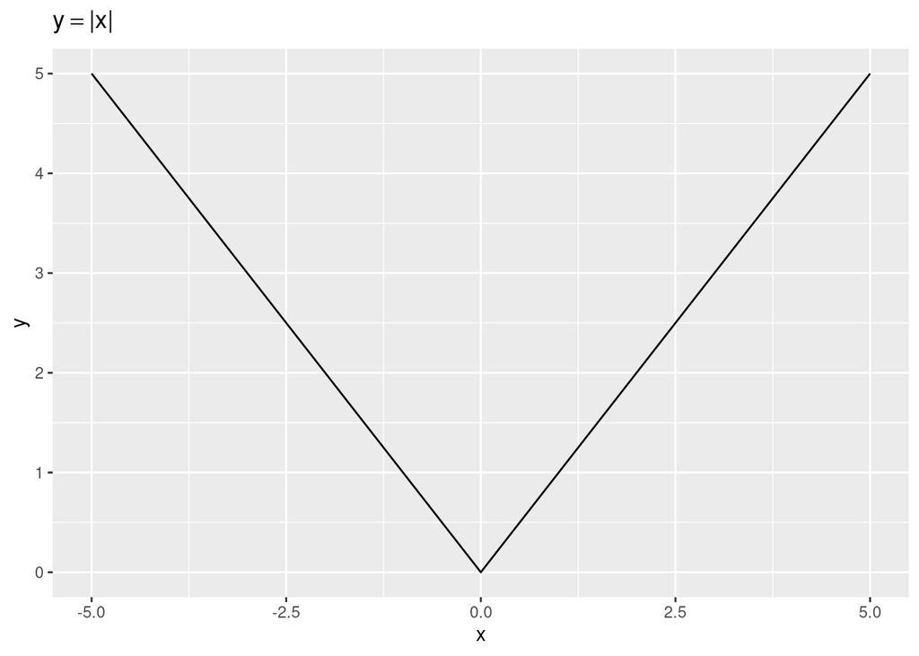

```r
ggplot(data = tibble(x = c(-5, 5)), mapping = aes(x = x)) +
  stat_function(fun = function(x) { abs(x) }) +
  labs(title = TeX('$y = |x|$'))
```

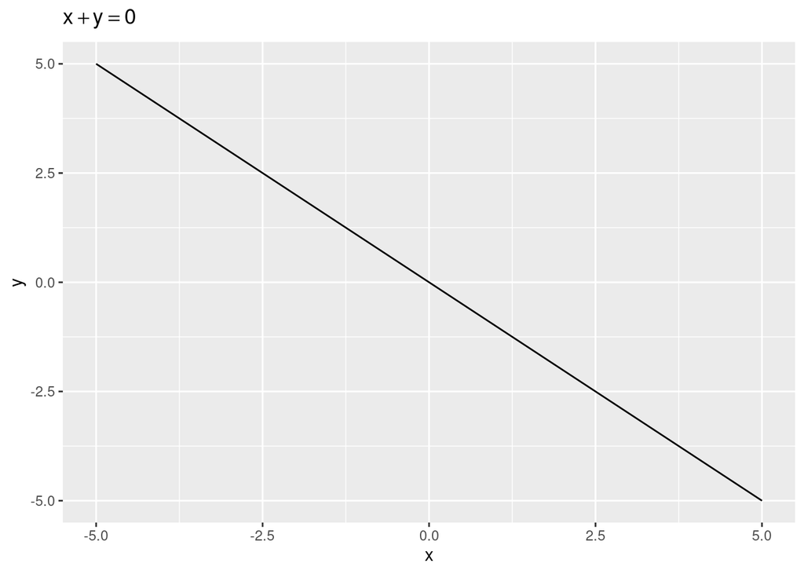

```r
ggplot(data = tibble(x = c(-5, 5)), mapping = aes(x = x)) +
  stat_function(fun = function(x) { -x }) +
  labs(title = TeX('$x + y = 0$'))
```

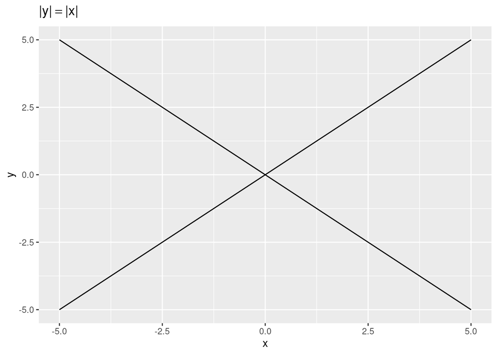

```r
ggplot(data = tibble(x = c(-5, 5)), mapping = aes(x = x)) +
  stat_function(fun = function(x) { abs(x) }) +
  stat_function(fun = function(x) { -abs(x) }) +
  labs(title = TeX('$|y| = |x|$'))
```

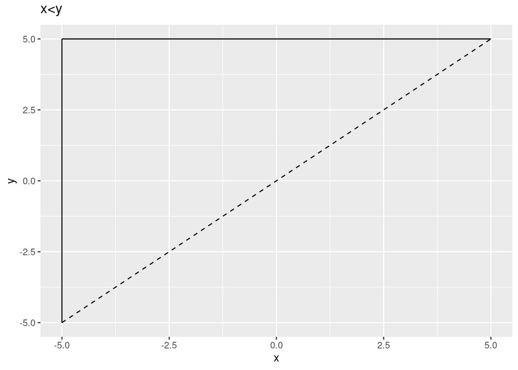

```r
ggplot(data = tibble(x = c(-5, 5)), mapping = aes(x = x)) +
  stat_function(fun = function(x) { x }, linetype = "dashed") +
  geom_segment(data = tibble(x = -5, xend = -5, y = -5, yend = 5),
               mapping = aes(x = x, xend = xend, y = y, yend = yend)) +
  geom_segment(data = tibble(x = -5, xend = 5, y = 5, yend = 5),
               mapping = aes(x = x, xend = xend, y = y, yend = yend)) +
  labs(title = TeX('$x < y$'))
```

2. If $R$ is a binary relation, show that $R \subseteq \mathscr{D}(R) \times \mathscr{R}(R)$
   - $\mathscr{D}(R) \times \mathscr{R}(R) = \{(w, z): (\exists y)((w, y) \in R) \land (\exists x)((x, z) \in R)\}$
     - If $y = z \land x = w$ then $(x, y) \in R \land (x, y) \in \mathscr{D}(R) \times \mathscr{R}(R)$
     - However we can have that $(w, z) \in \mathscr{D}(R) \times \mathscr{R}(R)$ but $w \neq x \land z \neq y$. If this is the case $(w, z) \notin R$
       - Therefore $R \subseteq \mathscr{D}(R) \times \mathscr{R}(R)$
         - An example is $R = \{(x, y): x \in B \land y \in B \land y = |x| \}$
           - $0 \in \mathscr{D}(R) \land 0 \in \mathscr{R}(D) \land 0 \in \mathscr{R}(D)$ so $(0,0) \in \mathscr{D}(R) \times \mathscr{R}(R) \land (0,1) \in \mathscr{D}(R) \times \mathscr{R}(R)$
           - In that sense $(0, 0) \in R$ but $(0, 1) \notin R$

## 1.28 Inverse and composition of relations

If $R$ is a relation the **inverse** of $R$, $R^{-1}$, is the set of all ordered pairs $(x, y)$ for which $(y, z) \in R$:

$$R^{-1} = \{(x, y): (y, x) \in R \}$$
In that sense $R^{-1}$ is obtained from $R$ by switching the first and second components of every ordered pair in $R$

We are going to introduce the following notation when $R$ is a relation:

$$(x, y) \in R \iff xRy$$
This notation make sense because we usually write $x < y$ or $x + y$ instead of $(x,y) \in \; <$ or $(x, y) \in +$

If $R$ and $S$ are relations the **compisition** of $R$ and $S$, $S \circ R$ is defined as_

$$S \circ R = \{(x,y): (\exists z)(xRz \land zRy) \}$$
Thus, $x(S \circ R)y$ means that their is an *“intermediate”* object $z$ such that $xRz \land zRy$. Note that $R$ is applied before $S$

## 1.29 Inverse and composition of relations exercises and solutions

1. Let $A$ be the set of people, and let $F, M, P$ be the fatherhood, motherhood and parenthood relations, respectively. In addition, let $B, S, H, W$ be the brother, sister, husband, wife relations, respectively
   1. Verifiy that $P^{-1} \circ H$ is the son-in-law relation
      - $P = \{ (x, y): x \in A \land y \in A \land x \text{ is a parent of } y \}$
      - $\begin{split} P^{-1} & = \{ (x, y): (y, x) \in P \} \\ & = \{ (x, y): x \in A \land y \in A \land x \text{ is a child of } y \} \end{split}$
      - $H = \{ (x, y): x \in A \land y \in A \land x \text{ is a husband of } y \}$
      - $\begin{split} P^{-1} \circ H = \{(x, y): (\exists z)(xHz \land zP^{-1}y) \} & = \{(x, y): x \text{ is a husband of } z \land z \text{ is a child of } y \} \\ & = \{ (x, y): x \text{ is a son in law of } y \} \end{split}$
   2. Find simple names, if possible, for: $H^{-1}$, $F \cup M$, $H \cup W$, $M \circ F$, $F \circ M$, $P \circ M$, $M \circ P$, $P \circ B$, $(H \cup W) \circ F$, $(P \circ B) \cup ((P \circ S) \circ H)$
      - $\begin{split} H^{-1} & = \{(x,y): (y, x) \in H \} \\ & = \{(x,y): x \in A \land y \in A \land x \text{ is a wife of } y \} \end{split}$
      - $\begin{split} F \cup M & = \{(x,y): x \in A \land y \in A \land x \text{ is a father of } y \} \cup \{(x,y): x \in A \land y \in A \land x \text{ is a mother of } y \} \\ & = \{(x,y): x \in A \land y \in A \land x \text{ is a parent of } y \} \\ & = P \end{split}$
      - $\begin{split} H \cup W & = \{(x,y): x \in A \land y \in A \land x \text{ is a husband of } y \} \cup \{(x,y): x \in A \land y \in A \land x \text{ is a wife of } y \} \\ & = \{(x,y): x \in A \land y \in A \land x \text{ is a partner of } y \} \end{split}$
      - $\begin{split} M \circ F & = \{(x,y): (\exists z)(xFz \land zMy) \} \\ & = \{(x,y): x \in A \land y \in A \land z \in A \land x \text{ is a father of } z \land z \text{ is a mother of } y \} \\ & = \{(x,y): x \in A \land y \in A \land x \text{ is a grandfather of } y \} \end{split}$
      - $\begin{split} F \circ M & = \{(x,y): (\exists z)(xMz \land zFy) \} \\ & = \{(x,y): x \in A \land y \in A \land z \in A \land x \text{ is a mother of } z \land z \text{ is a father of } y \} \\ & = \{(x,y): x \in A \land y \in A \land x \text{ is a grandmother of } y \} \end{split}$
      - $\begin{split} P \circ M & = \{(x,y): (\exists z)(xMz \land zPy) \} \\ & = \{(x,y): x \in A \land y \in A \land z \in A \land x \text{ is a mother of } z \land z \text{ is a parent of } y \} \\ & = \{(x,y): x \in A \land y \in A \land x \text{ is a grandmother of } y \} \end{split}$
      - $\begin{split} M \circ P & = \{(x,y): (\exists z)(xPz \land zMy) \} \\ & = \{(x,y): x \in A \land y \in A \land z \in A \land x \text{ is a parent of } z \land z \text{ is a mother of } y \} \\ & = \{(x,y): x \in A \land y \in A \land x \text{ is a grandparent of } y \} \end{split}$
      - $\begin{split} P \circ B & = \{(x,y): (\exists z)(xPz \land zMy) \} \\ & = \{(x,y): x \in A \land y \in A \land z \in A \land x \text{ is a brother of } z \land z \text{ is a parent of } y \} \\ & = \{(x,y): x \in A \land y \in A \land x \text{ is an uncle of } y \} \end{split}$
      - $\begin{split} (H \cup W) \circ F & = \{(x,y): x \in A \land y \in A \land x \text{ is a partner of } y \} \circ F \\ & = Par \circ F \\ & = \{(x,y): (\exists z)(xFz \land zPary) \} \\ & = \{(x,y): x \in A \land y \in A \land z \in A \land x \text{ is a parent of } z \land z \text{ is a partner of } y \} \\ & = \{(x,y): x \in A \land y \in A \land x \text{ is a parent-in-law of } y \} \end{split}$
      - $\begin{split} (P \circ B) \cup ((P \circ S) \circ H) & = \{(x,y): x \in A \land y \in A \land x \text{ is an uncle of } y \} \cup (\{(x,y): x \in A \land y \in A \land x \text{ is an aunt of } y \}) \circ H \\ & = U \cup (A \circ H) \\ & = U \cup \{(x,y): (\exists z)(xHz \land zAy) \} \\ & = U \cup \{(x,y): x \in A \land y \in A \land z \in A \land x \text{ is a husband of } z \land z \text{ is an aunt of } y \} \\ & = U \cup \{(x,y): x \in A \land y \in A \land x \text{ is a uncle-in-law of } y \} \\ & = U \cup U^{*} \\ & = \{(x,y): x \in A \land y \in A \land x \text{ is an uncle or uncle-in-law of } y \} \end{split}$
   3. Express in symbols the following relations: child, sibling, grandchild, daughter-in-law, mother-in-law
      - child: $P^{-1}$
      - sibling: $B \cup S$
      - grandchild: $(P \circ P)^{-1}$
      - daughter-in-law: $P^{-1} \circ W$
      - mother-in-law: $(P^{-1} \circ (H \cup W))^{-1}$
2. Show that, if $R$ is a relation, then $\mathscr{D}(R^{-1}) = \mathscr{R}(R)$ and $\mathscr{R}(R^{-1}) = \mathscr{D}(R)$
   - $\begin{split} \mathscr{D}(R^{-1}) & = \{x: (\exists y)((x,y) \in R^{-1})\} \\ & = \{x: (\exists y)((y,x) \in R)\} \\ & = \mathscr{R}(R) \end{split}$
   - $\begin{split} \mathscr{R}(R^{-1}) & = \{y: (\exists x)((x,y) \in R^{-1})\} \\ & = \{y: (\exists x)((y,x) \in R)\} \\ & = \mathscr{D}(R) \end{split}$
3. Let $B$ be the set of real numbers let:

$$S = \{(x,y): x \in B \land y \in B \land y = x^2\}$$
$$W = \{(x,y): x \in B \land y \in B \land y = -x\}$$
$$R = \{(x,y): x \in B \land y \in B \land y = x + 1\}$$

1. Describe the following relations: $S^{-1}$, $R^{-1}$, $W^{-1}$, $S \circ S$, $W \circ W$, $R \circ R$, $S \circ W$, $W \circ S$, $S \circ R$, $R \circ S$, $R \circ W$, $W \circ R$
   - $\begin{split} (x,y) \in S^{-1} & \iff (y,x) \in S \\ & \iff y \in B \land x \in B \land x = y^2 \\ & \iff y \in B \land x \in B \land \sqrt{x} = |y| \end{split}$
     - $S^{-1} = \{(x,y): x \in B \land y \in B \land |y| = \sqrt{x} \}$
   - $\begin{split} (x,y) \in R^{-1} & \iff (y,x) \in R \\ & \iff y \in B \land x \in B \land x = y + 1 \\ & \iff y \in B \land x \in B \land x - 1 = y \end{split}$
     - $R^{-1} = \{(x,y): x \in B \land y \in B \land y = x - 1\}$
   - $\begin{split} (x,y) \in W^{-1} & \iff (y,x) \in W \\ & \iff y \in B \land x \in B \land x = -y \\ & \iff y \in B \land x \in B \land -x = y \end{split}$
     - $W^{-1} = \{(x,y): x \in B \land y \in B \land y = -x\}$
       - In this case $W = W^{-1}$
   - $\begin{split} x(S \circ S)y & \iff (\exists z)(xSz \land zRy) \\ & \iff x \in B \land y \in B \land z \in B \land z = x^2 \land y = z^2 \\ & \iff x \in B \land y \in B \land y = (x^2)^2 \\ & \iff x \in B \land y \in B \land y = x^4 \\ \end{split}$
     - $S \circ S = \{(x,y): x \in B \land y \in B \land y = x^4 \}$
   - $\begin{split} x(W \circ W)y & \iff (\exists z)(xWz \land zWy) \\ & \iff x \in B \land y \in B \land z \in B \land z = -x \land y = -z \\ & \iff x \in B \land y \in B \land y = -(-x) \\ & \iff x \in B \land y \in B \land y = x \\ \end{split}$
     - $W \circ W = \{(x,y): x \in B \land y \in B \land y = x \}$
   - $\begin{split} x(R \circ R)y & \iff (\exists z)(xRz \land zRy) \\ & \iff x \in B \land y \in B \land z \in B \land z = x + 1 \land y = z + 1 \\ & \iff x \in B \land y \in B \land y = (x + 1) + 1 \\ & \iff x \in B \land y \in B \land y = x + 2 \\ \end{split}$
     - $R \circ R = \{(x,y): x \in B \land y \in B \land y = x + 2 \}$
   - $\begin{split} x(S \circ W)y & \iff (\exists z)(xWz \land zSy) \\ & \iff x \in B \land y \in B \land z \in B \land z = -x \land y = z^2 \\ & \iff x \in B \land y \in B \land y = (-x)^2 \\ & \iff x \in B \land y \in B \land y = x^2 \\ \end{split}$
     - $S \circ W = \{(x,y): x \in B \land y \in B \land y = x^2 \}$
   - $\begin{split} x(W \circ S)y & \iff (\exists z)(xSz \land zWy) \\ & \iff x \in B \land y \in B \land z \in B \land z = x^2 \land y = -z \\ & \iff x \in B \land y \in B \land y = -(x^2) \\ & \iff x \in B \land y \in B \land y = -x^2 \\ \end{split}$
     - $W \circ S = \{(x,y): x \in B \land y \in B \land y = -x^2 \}$
   - $\begin{split} x(S \circ R)y & \iff (\exists z)(xRz \land zSy) \\ & \iff x \in B \land y \in B \land z \in B \land z = x + 1 \land y = z^2 \\ & \iff x \in B \land y \in B \land y = (x + 1)^2 \end{split}$
     - $S \circ R = \{(x,y): x \in B \land y \in B \land y = (x + 1)^2 \}$
   - $\begin{split} x(R \circ S)y & \iff (\exists z)(xSz \land zRy) \\ & \iff x \in B \land y \in B \land z \in B \land z = x^2 \land y = z + 1 \\ & \iff x \in B \land y \in B \land y = x^2 + 1 \end{split}$
     - $R \circ S = \{(x,y): x \in B \land y \in B \land y = x^2 + 1 \}$
   - $\begin{split} x(R \circ W)y & \iff (\exists z)(xWz \land zRy) \\ & \iff x \in B \land y \in B \land z \in B \land z = -x \land y = z + 1 \\ & \iff x \in B \land y \in B \land y = -x + 1 \end{split}$
     - $R \circ W = \{(x,y): x \in B \land y \in B \land y = -x + 1 \}$
   - $\begin{split} x(W \circ R)y & \iff (\exists z)(xRz \land zWy) \\ & \iff x \in B \land y \in B \land z \in B \land z = x + 1 \land y = -z \\ & \iff x \in B \land y \in B \land y = -(x + 1) \\ & \iff x \in B \land y \in B \land y = -x - 1 \end{split}$
     - $W \circ R = \{(x,y): x \in B \land y \in B \land y = -x - 1 \}$
2. Determine the domain and range of $S, W, R$ and of the relations in Part a
   - $\mathscr{D}(S) \land \mathscr{R}(S)$
     - $\begin{split} \mathscr{D}(S) & = \{x: (\exists y)(xSy) \} \\ & = \{x: x \in B \land y \in B \land y = x^2 \} \\ & = \{x: x \in B \} \end{split}$
     - $\begin{split} \mathscr{R}(S) & = \{y: (\exists x)(xSy) \} \\ & = \{y: x \in B \land y \in B \land y = x^2 \} \\ & = \{y: y \in B \land y \geq 0 \} \end{split}$
   - $\mathscr{D}(R) \land \mathscr{R}(R)$
     - $\begin{split} \mathscr{D}(R) & = \{x: (\exists y)(xRy) \} \\ & = \{x: x \in B \land y \in B \land y = x + 1 \} \\ & = \{x: x \in B \} \end{split}$
     - $\begin{split} \mathscr{R}(R) & = \{y: (\exists x)(xRy) \} \\ & = \{y: x \in B \land y \in B \land y = x + 1 \} \\ & = \{y: y \in B \} \end{split}$
   - $\mathscr{D}(W) \land \mathscr{R}(W)$
     - $\begin{split} \mathscr{D}(W) & = \{x: (\exists y)(xWy) \} \\ & = \{x: x \in B \land y \in B \land y = -x \} \\ & = \{x: x \in B \} \end{split}$
     - $\begin{split} \mathscr{R}(W) & = \{y: (\exists x)(xWy) \} \\ & = \{y: x \in B \land y \in B \land y = -x \} \\ & = \{y: y \in B \} \end{split}$
   - $\mathscr{D}(S^{-1}) \land \mathscr{R}(S^{-1})$
     - $\begin{split} \mathscr{D}(S^{-1}) & = \{x: (\exists y)(xS^{-1}y) \} \\ & = \{x: x \in B \land y \in B \land \sqrt{x} = |y| \} \\ & = \{x: x \in B \land x \geq 0 \} \end{split}$
     - $\begin{split} \mathscr{R}(S^{-1}) & = \{y: (\exists x)(xS^{-1}y) \} \\ & = \{y: x \in B \land y \in B \land \sqrt{x} = |y| \} \\ & = \{y: y \in B \} \end{split}$
   - $\mathscr{D}(S \circ S) \land \mathscr{R}(S \circ S)$
     - $\begin{split} \mathscr{D}(S \circ S) & = \{x: (\exists y)(x(S \circ S)y) \} \\ & = \{x: x \in B \land y \in B \land y = x^4 \} \\ & = \{x: x \in B \} \end{split}$
     - $\begin{split} \mathscr{R}(S \circ S) & = \{y: (\exists x)(x(S \circ S)y) \} \\ & = \{y: x \in B \land y \in B \land y = x^4 \} \\ & = \{y: y \in B \land y \geq 0 \} \end{split}$
   - $\mathscr{D}(W \circ W) \land \mathscr{R}(W \circ W)$
     - $\begin{split} \mathscr{D}(W \circ W) & = \{x: (\exists y)(x(W \circ W)y) \} \\ & = \{x: x \in B \land y \in B \land y = x \} \\ & = \{x: x \in B \} \end{split}$
     - $\begin{split} \mathscr{R}(W \circ W) & = \{y: (\exists x)(x(W \circ W)y) \} \\ & = \{y: x \in B \land y \in B \land y = x \} \\ & = \{y: y \in B \} \end{split}$
   - $\mathscr{D}(R \circ R) \land \mathscr{R}(R \circ R)$
     - $\begin{split} \mathscr{D}(R \circ R) & = \{x: (\exists y)(x(R \circ R)y) \} \\ & = \{x: x \in B \land y \in B \land y = x + 2 \} \\ & = \{x: x \in B \} \end{split}$
     - $\begin{split} \mathscr{R}(R \circ R) & = \{y: (\exists x)(x(R \circ R)y) \} \\ & = \{y: x \in B \land y \in B \land y = x + 2 \} \\ & = \{y: y \in B \} \end{split}$
   - $\mathscr{D}(S \circ W) \land \mathscr{R}(S \circ W)$
     - $\begin{split} \mathscr{D}(S \circ W) & = \{x: (\exists y)(x(S \circ W)y) \} \\ & = \{x: x \in B \land y \in B \land y = x^2 \} \\ & = \{x: x \in B \} \end{split}$
     - $\begin{split} \mathscr{R}(S \circ W) & = \{y: (\exists x)(x(S \circ W)y) \} \\ & = \{y: x \in B \land y \in B \land y = x^2 \} \\ & = \{y: y \in B \land y \geq 0 \} \end{split}$
   - $\mathscr{D}(W \circ S) \land \mathscr{R}(W \circ S)$
     - $\begin{split} \mathscr{D}(W \circ S) & = \{x: (\exists y)(x(W \circ S)y) \} \\ & = \{x: x \in B \land y \in B \land y = -x^2 \} \\ & = \{x: x \in B \} \end{split}$
     - $\begin{split} \mathscr{R}(W \circ S) & = \{y: (\exists x)(x(W \circ S)y) \} \\ & = \{y: x \in B \land y \in B \land y = -x^2 \} \\ & = \{y: y \in B \land y \leq 0 \} \end{split}$
   - $\mathscr{D}(S \circ R) \land \mathscr{R}(S \circ R)$
     - $\begin{split} \mathscr{D}(S \circ R) & = \{x: (\exists y)(x(S \circ R)y) \} \\ & = \{x: x \in B \land y \in B \land y = (x + 1)^2 \} \\ & = \{x: x \in B \} \end{split}$
     - $\begin{split} \mathscr{R}(S \circ R) & = \{y: (\exists x)(x(S \circ R)y) \} \\ & = \{y: x \in B \land y \in B \land y = (x + 1)^2 \} \\ & = \{y: y \in B \land y \geq 0 \} \end{split}$
   - $\mathscr{D}(R \circ S) \land \mathscr{R}(R \circ S)$
     - $\begin{split} \mathscr{D}(R \circ S) & = \{x: (\exists y)(x(R \circ S)y) \} \\ & = \{x: x \in B \land y \in B \land y = x^2 + 1 \} \\ & = \{x: x \in B \} \end{split}$
     - $\begin{split} \mathscr{R}(R \circ S) & = \{y: (\exists x)(x(R \circ S)y) \} \\ & = \{y: x \in B \land y \in B \land y = x^2 + 1 \} \\ & = \{y: y \in B \land y \geq 1 \} \end{split}$
   - $\mathscr{D}(R \circ W) \land \mathscr{R}(R \circ W)$
     - $\begin{split} \mathscr{D}(R \circ W) & = \{x: (\exists y)(x(R \circ W)y) \} \\ & = \{x: x \in B \land y \in B \land y = -x + 1 \} \\ & = \{x: x \in B \} \end{split}$
     - $\begin{split} \mathscr{R}(R \circ W) & = \{y: (\exists x)(x(R \circ W)y) \} \\ & = \{y: x \in B \land y \in B \land y = -x + 1 \} \\ & = \{y: y \in B \} \end{split}$
   - $\mathscr{D}(W \circ R) \land \mathscr{R}(W \circ R)$
     - $\begin{split} \mathscr{D}(W \circ R) & = \{x: (\exists y)(x(W \circ R)y) \} \\ & = \{x: x \in B \land y \in B \land y = -x - 1 \} \\ & = \{x: x \in B \} \end{split}$
     - $\begin{split} \mathscr{R}(W \circ R) & = \{y: (\exists x)(x(W \circ R)y) \} \\ & = \{y: x \in B \land y \in B \land y = -x - 1 \} \\ & = \{y: y \in B \} \end{split}$

## 1.30 Reflexivity, symmetry and transitivity

Consider a relation $R$ and a set $A$:

- $R$ is **reflexive** in $A$ $\iff (\forall x)(x \in A \implies xRx)$
- $R$ is **irreflexive** in $A$ $\iff (\forall x)(x \in A \implies \neg xRx)$
- $R$ is **symmetric** in $A$ $\iff (\forall x)(\forall y)((x \in A \land y \in A \land xRy) \implies yRx)$
- $R$ is **transitive** in $A$ $\iff (\forall x)(\forall y)(\forall z)((x \in A \land y \in A \land z \in A \land xRy \land yRz) \implies xRz)$

## 1.31 Reflexivity, symmetry and transitivity exercises and solutions

1. Determine whether each of the following relations $R$ is reflexive, symmetric or transitive in the given set $A$
1. $A$ is the set of positive integers
   - $\begin{split} R & = \{(x,y): x \in A \land y \in A \land y \text{ is divisible by } x \} \\ & = \{(x,y): x \in A \land y \in A \land (\exists !k)(k \in \mathbb{Z} \land y = kx) \} \end{split}$
     - $R$ is reflexive because if $x \in A$ then $x = 1x$ where $1 \in \mathbb{Z}$ and $1$ is unique
     - $R$ is not symmetric because $2R4$ but not $4R2$ because there is no $k \in \mathbb{Z}$ such that $2 = k4$
     - $R$ is transitive because if $x \in A, y \in A \land z \in A \land xRy \land yRz$ then $y = k_1x \land z = k_2y$ where $k_1 \in \mathbb{Z}$, $k_1$ is unique, $k_2 \in \mathbb{Z}$ and $k_2$ is unique. Therefore $z = k_1k_2x$ where $k_1k_2 \in \mathbb{Z}$ and $k_1k_2$ is unique
2. $A$ is the set of all line segments in the plane
   - $\begin{split} R & = \{(x,y): x \in A \land y \in A \land x \text{ is longer than } y \} \\ & = \{(x,y): x = (x_1, x_2) \in A \land y = (y_1, y_2) \in A \land |x_2 - x_1| > |y_2 - y_1| \} \end{split}$
     - $R$ is not reflexive because it is not true that |x_2 - x_1| > |x_2 - x_1|
     - $R$ is not symmetric because if |x_2 - x_1| > |y_2 - y_1| it is not the case that |y_2 - y_1| > |x_2 - x_1|
     - $R$ is transitive because if $|x_2 - x_1| > |y_2 - y_1| \land |y_2 - y_1| > |z_2 - z_1|$ then $|x_2 - x_1| > |z_2 - z_1|$
3. $A$ is the set of all lines in the plane
   - $\begin{split} R & = \{(x,y): x \in A \land y \in A \land x \text{ is perpendicular to } y \} \\ & = \{(x,y): x \in A \land y \in A \land x \bot y \} \end{split}$
     - $R$ is not reflexive because $x$ is not parallel to itself
     - $R$ is symmetric because if $x \in A \land y \in A \land x \bot y$ then $y \bot x$
     - $R$ is not transitive. For example, we have that $x \bot y \land y \bot x$ because $R$ is symmetric. However it is not the case that $x \bot x$ because $R$ isn’t reflexive
4. $A$ is the set of all subsets of a given set $B$
   - $\begin{split} R & = \{(x,y): x \in A \land y \in A \land x \cap y \neq \emptyset \} \\ & = \{(x,y): x \in \mathscr{P}(B) \land y \in \mathscr{P}(B) \land x \cap y \neq \emptyset \} \end{split}$
     - $R$ isn’t reflexive because $\emptyset \in \mathscr{P}(B)$ but $\emptyset \cap \emptyset = \emptyset$
     - $R$ is symmetric because if $x \in \mathscr{P}(B) \land y \in \mathscr{P}(B) \land x \cap y \neq \emptyset$ then $y \cap x \neq \emptyset$
     - $R$ can and can’t be transitive depending on the set $B$
       - For $B = \emptyset$ we have that $\mathscr{P}(B) = \{ \emptyset \}$. Therefore:
         - $(\forall x)(\forall y)(\forall z)((\emptyset \in \mathscr{P}(B) \land \emptyset R \emptyset \land \emptyset R \emptyset) \implies \emptyset R \emptyset)$ is true because the antecedent and consequent in the conditional are false. So $R$ is transitive.
           - A similar argument applies if $B = \{ b_1 \}$ where $\mathscr{P}(B) = \{ \emptyset, \{ b_1 \} \}$.
       - For $B = \{ b_1, b_2 \}$ we have that $\mathscr{P}(B) = \{ \emptyset, \{ b_1 \}, \{ b_2 \}, \{ b_1, b_2 \} \}$. So, for example:
         - $\{ b_1 \} \cap \{ b_1, b_2 \} \neq \emptyset \land \{ b_1, b_2 \} \cap \{ b_2 \} \neq \emptyset$ but $\{ b_1 \} \cap \{ b_2 \} = \emptyset$. So $R$ isn’t transitive
           - A similar argument applies if $B$ is a set with three or more elements
5. $A$ is the set of all subsets of a given set $B$
   - $\begin{split} R & = \{(x,y): x \in A \land y \in A \land x \subseteq y \} \\ & = \{(x,y): x \in \mathscr{P}(B) \land y \in \mathscr{P}(B) \land x \subseteq y \} \end{split}$
     - $R$ is reflexive because $x \subseteq x$ for any $x \in \mathscr{P}(B)$
     - $R$ is symmetric only if $B = \emptyset$. If $B \neq \emptyset$ we have for example that if $\emptyset \in \mathscr{P}(B) \land y \in \mathscr{P}(B) \land y \neq \emptyset$ then $\emptyset \subseteq y$ but not $y \subseteq \emptyset$
     - $R$ is transitive because if $x \in \mathscr{P}(B) \land y \in \mathscr{P}(B) \land z \in \mathscr{P}(B) \land x \subseteq y \land y \subseteq z$ then $x \subseteq z$
6. $A$ is the set of all people
   - $R = \{(x,y): x \in A \land y \in A \land x \text{ is the ancestor of } y \}$
     - $R$ is not reflexive because $x$ isn’t an ancestor of itself
     - $R$ is not symmetric because if $x \text{ is the ancestor of } y \}$ then it is not the case that $y \text{ is the ancestor of } x \}$
     - $R$ is transitive because if $x \text{ is the ancestor of } y \land y \text{ is the ancestor of } z$ then $x \text{ is the ancestor of } z$
7. $A$ is any set
   - $R = I_A = \{(x,y): x \in A \land y \in A \land x = y \}$
     - $R$ is reflexive because $x = x$ for any $x \in A$
       - For the case of $A = \emptyset$, $I_A$ is reflexive because $x \in \emptyset \implies xI_{A}x$ is true since the antecedent is false
     - $R$ is symmetric because if $x \in A \land y \in A \land x = y$ then $y = x$
       - For the case of $A = \emptyset$, $I_A$ is symmetric because $(x \in A \land y \in A \land x \neq y) \implies y \neq x$ is true since the antecedent is false
     - $R$ is transitive because if $x \in A \land y \in A \land z \in A \land x = y \land y = z$ then $x = z$
       - For the case of $A = \emptyset$, $I_A$ is transitive because $x \in A \land y \in A \land z \in A \land x = y \land y = z$ is true since the antecedent is false
8. $A$ is any set
   - $R = \{(x,y): x \in A \land y \in A \land x \neq y \}$
     - $R$ is reflexive for $A = \emptyset$ because $x \in \emptyset \implies xI_{A}x$ is true since the antecedent is false. However if $A \neq \emptyset$, $R$ is not reflexive because $x = x$
     - $R$ is symmetric because if $x \in A \land y \in A \land x \neq y$ then $y \neq x$
       - For the case of $A = \emptyset$, $R$ is symmetric because $(x \in A \land y \in A \land x \neq y) \implies y \neq x$ is true since the antecedent is false
     - $R$ is transitive if $A = \emptyset$ because $(x \in A \land y \in A \land z \in A \land xRy \land yRz) \implies xRz$ is true since the antecedent is false. However if $A \neq \emptyset$, $R$ isn’t transitive because if $x \in A \land y \in A \land z \in A \land x \neq y \land y \neq x$ then is false that $x \neq x$
2. A relation $R$ is said to be **asymmetric** in $A$ if and only if $xRy$ implies $\neg(yRx)$ for all $x$ and $y$ in $A$. A relation $R$ is said to be **antisymmetric** in $A$ if and only if $xRy \land yRx$ implies $x = y$ for all $x$ and $y$ in $A$
   1. Give examples of relations $R$ and sets $A$ such that
      - $R$ is asymmetric in $A$
        - $A = \mathbb{R}$
        - $R = \{(x,y): x \in A \land y \in A \land x > y \}$
      - $R$ is not asymmetric in $A$
        - $A = \mathbb{R}$
        - $R = \{(x,y): x \in A \land y \in A \land x = y \}$
      - $R$ is antisymmetric in $A$
        - $A$ is any set
        - $R = \{(x,y): x \in A \land y \in A \land x \subseteq y \}$
      - $R$ is not antisymmetric in $A$
        - $A = \mathscr{P}(B)$ where $B$ is any set
        - $R = \{(x,y): x \in A \land y \in A \land x \cap y \neq \emptyset \}$
   2. Prove that asymmetry implies antisymmetric
      - $R$ is antisymmetric in $A$ if and only if $(\forall x)(\forall y)((x \in A \land y \in A \land xRy \land yRx) \implies x = y)$
      - $R$ is asymmetric in $A$ if and only if $(\forall x)(\forall y)((x \in A \land y \in A \land xRy) \implies \neg(yRx))$
        - If $R$ is asymmetric in $A$, $x \in A$, $y \in A$ and $x = y$ then by *reductio ad absurdum* $\neg(xRy)$. In particular if $R$ is asymmetric and $x \in A$ then $\neg(xRx)$. In that sense, if $R$ is asymmetric in $A$, $x \in A$ and $y \in A$ then $x \neq y \iff xRy \oplus yRx$ where $\oplus$ refers to the exclusive or
        - We can rewrite the definition of antisymmetric as: $R$ is antisymmetric in $A$ if and only if $(\forall x)(\forall y)(x \neq y \implies (x \notin A \lor y \notin A \lor \neg(xRy) \lor \neg(yRx)))$
        - We have that if $R$ is asymmetric in $A$, $x \in A$, $y \in A$ then $x \neq y \iff xRy \oplus xRy$. Let us assume that $xRy$ without loss of generality. Since $R$ is asymmetric $xRy \implies \neg(yRx)$. Therefore we have that:
          - $R$ is asymmetric in $A$, $x \in A$, $y \in A$ and $xRy$ then $x \neq y \implies \neg(yRx)$
      - So $R$ is also antisymmetric
   3. Let $R$ be the $\leq$ relation on the set of integers. Sohw that $R$ is antisymmetric but not asymmetric on the set on integers
      - $R = \{(x,y): x\in \mathbb{Z} \land y \in \mathbb{Z} \land x \leq y \}$
        - Let $x \leq y \land y \leq x$ then $x = y$. So $\leq$ is antisymmetric in $\mathbb{Z}$
        - Let $x \leq x$ but $\neg(x \leq x) = x > x$ where $x > x$ is not true. Therefore $R$ is not asymmetric on the set on integers
   4. If a relation $R$ is irreflexive in a set A and transitive in A, prove that $R$ is asymmetric in A
      - Let $R$ be a transitive and irreflexive relation in a set A where $xRy$ for any $x \in A \land y \in A$
        - We are going to prove that $R$ is symmetric by *reduction ad absurdum*
        - Let assume that $yRx$ so $xRy$ an transitivity implies that $xRy \land yRx \implies xRy$. However $R$ is an irreflexive relation
          - Therefore $yRx$ is not true. So $\neg(yRx)$ must be true.
      - We conclude that $R$ is asymmetric
3. Show that a relation $R$ is reflexive in a set $A$ if and only if $I_A \subseteq R$, where $I_A$ is the identity relation on $A$
   - $(\forall x)(x \in A \implies xRx) \iff I_A \subseteq R$
   - $I_A = \{(x,y): x \in A \land y \in A \land x = y \}$
     - Assume that $(\forall x)(x \in A \implies xRx)$
       - $\begin{split} xI_Ay & \implies x \in A \land y \in A \land x = y \\ & \implies x \in A \land x \in A \land x = y\\ & \implies x \in A \land x = y \\ & \implies xRx \land x = y \\ & \implies xRy \end{split}$
     - Assume that $I_A \subseteq R$
       - $\begin{split} x \in A & \implies xI_Ax \\ & \implies xRx \end{split}$
4. Show that a relation $R$ is irreflexive in a set $A$ if and only if $R$ and $I_A$ are disjoint
   - $(\forall x)(x \in A \implies \neg(xRx)) \iff R \cap I_A = \emptyset$
   - $I_A = \{(x,y): x \in A \land y \in A \land x = y \}$
     - Assume that $(\forall x)(x \in A \implies \neg(xRx))$
       - $\begin{split} (x, y) \in I_A & \iff x \in A \land y \in A \land x = y \\ & \implies x \in A \land x \in A \land x = y \\ & \implies x \in A \land x = y \\ & \implies \neg(xRx) \land x = y \\ & \implies (x, x) \notin R \land x = y \\ & \implies (x, y) \notin R \\ \end{split}$
     - Assume that $R \cap I_A = \emptyset$
       - $\begin{split} x \in A & \implies (x, x) \in I_A \\ & \implies (x, x) \notin R \\ & \implies \neg(xRx) \end{split}$
5. Assume $R \subseteq A \times A$. Show that $R$ is symmetric in $A$ if and only if $R = R^{-1}$
   - $(\forall x)(\forall y)((x \in A \land y \in A \land xRy) \implies yRx) \iff R = R^{-1}$
     - Assume $(\forall x)(\forall y)((x \in A \land y \in A \land xRy) \implies yRx)$
       - $\begin{split} xR^{-1}y & \implies x \in A \land y \in A \land yRx \\ & \implies xRy \end{split}$
     - Assume $R = R^{-1}$
       - $\begin{split} x \in A \land y \in A \land xRy & \implies xR^{-1}y \\ & \implies yRx \end{split}$
6. Assume $R \subseteq A \times A$. Show that $R$ is transitive in $A$ if and only if $R \circ R \subseteq R$
   - $(\forall x)(\forall y)(\forall z)((x \in A \land y \in A \land z \in A \land xRy \land yRz) \implies xRz) \iff R \circ R \subseteq R$
     - Assume $(\forall x)(\forall y)(\forall z)((x \in A \land y \in A \land z \in A \land xRy \land yRz)$
       - $\begin{split} x(R \circ R)y & \implies (\exists z)(xRz \land zRy) \\ & \implies xRy \end{split}$
     - Assume $R \circ R \subseteq R$
       - $\begin{split} x \in A \land y \in A \land z \in A \land xRy \land yRz & \implies x(R \circ R)y \\ & \implies xRy \end{split}$
7. Let $A$ be the set of integers. Find a relation $R$ which is
   1. Reflexive and symmetric in $A$ but not transitive in $A$
      - $R = \{(x,y): x \in \mathbb{Z} \land y \in \mathbb{Z} \land x*y \geq 0 \}$
        - $R$ is reflexive:
          - $\forall(x)(x \in \mathbb{Z} \implies x*x \geq 0)$
        - $R$ is symmetric:
          - $\forall(x)((x \in \mathbb{Z} \land x*y \geq 0) \implies y*x \geq 0)$
        - $R$ is not transitive:
          - For example $-1*0 \geq 0 \land 1*0 \geq 0$ but not $-1*1 \geq 0$
   2. Reflexive and transitive in $A$ but not symmetric in $A$
      - $R = \{(x,y): x \in \mathbb{Z} \land y \in \mathbb{Z} \land x \leq y \}$
        - $R$ is reflexive:
          - $\forall(x)(x \in \mathbb{Z} \implies x \leq x)$
        - $R$ is transitive:
          - $(\forall x)(\forall y)(\forall z)((x \in \mathbb{Z} \land y \in \mathbb{Z} \land z \in \mathbb{Z} \land x \leq y \land y \leq z) \implies x \leq z)$
        - $R$ is not symmetric:
          - For example $0 \leq 1$ but not $1 \leq 0$
   3. Symmetric and transitive in $A$ but not reflexive in $A$
      - $R = \{(x,y): x \in \mathbb{Z} \land y \in \mathbb{Z} \land x \neq y \}$
        - $R$ is symmetric:
          - $\forall(x)((x \in \mathbb{Z} \land x \neq y) \implies y \neq x)$
        - $R$ is transitive:
          - $(\forall x)(\forall y)(\forall z)((x \in \mathbb{Z} \land y \in \mathbb{Z} \land z \in \mathbb{Z} \land x \neq y \land y \neq z) \implies x \neq z)$
        - $R$ is not reflexive:
          - It is not the case that $x \neq x$

## 1.32 Equivalence relations

A relation $R$ is said to be an **equivalence relation** in a set $A$ if and only if $R$ is reflexive, symmetric and transitive in $A$

Consider an equivalence relation $R$ in a set $A$. Each element $x$ of $A$ determines the set of all elements $z$ of $A$ such that $xRy$. This set is denoted $[x]$ and called the **equivalence class** of $x$ relative to the relation $R$:

$$[x] = \{z: z \in A \land xRz \land R \text{ is an equivalence relation }\}$$
If we want to be explicit about the specific relation associated with the equivalence class we can use the notation $[x]_R$

Consider an equivalence relation $R$ in a set $A$. Therefore two elements $x$ and $y$ determine the same equivalence class if and only if $xRy$:

$$[x] = [y] \iff xRy$$
**Proof**

- Assume $[x] = [y]$
  - $\begin{split} x \in [x] & \implies x \in [y] \\ \implies yRx \\ \implies xRy \\ \end{split}$
- Assume $xRy$
  - $\begin{split} z \in [x] \land w \in [y] & \implies zRx \land yRw \\ & \implies (zRx \land xRy) \land (yRw \land xRy) \\ & \implies (zRx \land xRy) \land (xRy \land yRw) \\ & \implies zRy \land xRw \\ & \implies yRz \land xRw \\ & \implies z \in [y] \land w \in [x] \\ & \implies [x] = [y] \end{split}$

If two equivalence classes are not identical then they are disjoint:

$$[x] \neq [y] \implies [x] \cap [y] = \emptyset$$
**Proof**

- $[x] \neq [y] \implies [x] \cap [y] = \emptyset$ is equivalent to $[x] \cap [y] \neq \emptyset \implies [x] = [y]$ and we have that $[x] = [y] \iff xRy$
  - $\begin{split} [x] \cap [y] \neq \emptyset & \implies (\exists z)(z \in [x] \land z \in [y]) \\ & \implies xRz \land yRz \\ & \implies xRz \land zRy \\ & \implies xRy \\ & \implies [x] = [y] \end{split}$

Therefore, and equivalence relation on a set $A$ divides $A$ into a collection of mutually exclusive subsets known as equivalence classes

## 1.33 Equivalence relations exercises and solutions

1. For each relation $R$ and set $A$ determine whether $R$ is an equivalence relation in $A$. If it is, describe the equivalence classes
   1. $A$ is the set of lines in the plane and $R = \{(x,y): x \in A \land (x = y \lor x \text{ is parallel to } y) \}$
   - If $x \in A$ then $xRx$ because $x = x$
   - If $x \in A \land xRy$ then $x = y$ or $x \text{ is parallel to } y) \}$. In any case $y = x$ or $y \text{ is parallel to } x) \}$
   - If $x \in A \land y \in A \land z \in A \land xRy \land yRz$ then $x = y \lor x \text{ is parallel to } y$ and $y = z \lor y \text{ is parallel to } z)$. In any case $x = z$ or $x \text{ is parallel to } z)$ so $xRz$
     - $[x]$ contains the line $x$ and all the lines parallel to $x$
   2. $A$ is the set of all people and $R = \{(x,y): x \in A \land y \in A \land x \text{ is related to } y \}$
      - There is not a known relation between $x$ and $x$ because it is not clear the meaning of $x \text{ is related to } x \}$. Therefore $R$ is not an equivalence relation.
   3. $A$ is the set of all directed line segments in a plane and $R = \{(x,y): x \in A \land y \in A \land x \text{ have the same length and the same direction } y \}$
      - If $x \in A$ then
        $$x = \{x_{1} = (x_{11}, x_{12}), x_{2} = (x_{21}, x_{22}) \land x_{1} \in \mathbb{R}^2 \land x_{2} \in \mathbb{R}^2 \land (x_{11} \neq x_{21} \lor x_{12} \neq x_{22})\}$$
        - The direction of $x$ can be $(x_{1}, x_{2})$ or $(x_{2}, x_{1})$. The first component in the direction of $x$ is the origin and the second component the end
        - The length of $x$ is $\sqrt{(x_{11} - x_{21})^2 + (x_{12} - x_{22})^2}$
      - If $x \in A$ then $xRx$ because $x$ has the same length and direction as itself
      - If $x \in A \land y \in A \land xRy$ then $yRx$ because $y$ have the same length and the same direction as $x$
      - If $x \in A \land y \in A \land z \in A \land xRy \land yRz$ then $x$ have the same length and the same direction as $y$ and $y$ have the same length and the same direction as $z$. Therefore, $x$ have the same length and direction as $z$ so $xRz$
        - $[x]$ contains the directed line segment $x$ and all the directed lines segments with the same length and direction as $x$
   4. $A$ is the set of all people and $R = \{(x,y): x \in A \land y \in A \land x \text{ has at least one parent in common with } y \}$
      - $R$ is not an equivalence class if $x \in A$ has two parents and $x$ has two brothers with different parents. $R$ would be an equivalence relation if it includes $x$ has exactly one parent in common with $y$ instead of $x$ has at least one parent in common with $y$
   5. $A$ is the set of all people and $R = \{(x,y): x \in A \land y \in A \land x \text{ live within one mile of } y \}$
      - $R$ is not an equivalence class if $x \in A$ live within two miles of $z$ but $y$ live within one mile of $x$ and $z$
   6. $A$ is the set of all points on earth and
      $$R = \{(x,y): x \in A \land y \in A \land x \text{ and } y \text{ are at the same distance from the north pole} \}$$
      - If $x \in A$ then $xRx$ because $x$ and $x$ are at the same distance from the north pole. Sounds weird in plain english but is true!
      - If $x \in A \land y \in A \land xRy$ then $yRx$ because $y$ and $x$ are at the same distance from the north pole.
      - If $x \in A \land y \in A \land z \in A \land xRy \land yRz$ then $x$ and $y$ are at the same distance from the north pole and also $y$ and $z$ are at the same distance from the north pole. Therefore $x$ and $z$ are at the same distance from the north pole so $xRz$
        - $[x]$ contains $x$ and all $z$s where $x$ and $z$ are at the same distance from the north pole
   7. $A$ is the set of all points inside a circle excluding the center of the circle and
      $$R = \{(x,y): x \in A \land y \in A \land (x = y or \text{ the line connecting } x \text{ and } y \text{ passes through the center of the circle}) \}$$
      - $R$ is not an equivalence class if $x \in A$, $y \in A$, $z \in A$, $x \neq y \neq z$, $xRy$ and $yRz$ then the line connecting $x$ and $z$ doesn’t pass through the center of the circle
   8. $A$ is the set of all subsets of the set of integers and $R = \{(x,y): x \in A \land y \in A \land (x - y) \cup (y - x) \text{ is finite} \}$
      - **Hint**: $xRy$ if and only if $x$ and $y$ differ by only a finite number of elements
      - $A = \mathscr{P}(\mathbb{Z})$
      - In this context a set $B\subseteq \mathbb{Z}$ is finite if $(\forall x)(x \in B \implies ((\exists z)(x \leq z \land z \in \mathbb{Z}) \land (\exists w)(x \geq w \land w \in \mathbb{Z})))$
        - $C \text{ is finite } \land D \text{ is finite } \iff C \cup D \text{ is finite }$
          - Assume that $C \text{ is finite } \land D \text{ is finite }$
            - $\begin{split} x \in C \land w_{1}, z_{1} \in \mathbb{Z} \land x \leq z_{1} \land x \geq w_{1} \in B \land w_{1}, z_{1} \in \mathbb{Z} \land y \leq z_{2} \land y \geq w_{2} & \implies z_{1}, w_{1}, z_{2}, w_{2} \in \mathbb{Z} \land (z_{2} \leq z_{1} \lor z_{2} > z_{1} \lor w_{2} \leq w_{1} \lor w_{2} > w_{1}) \\ & \implies (\forall u)(u \in C \cup D \implies ((\exists z)((z = z_1 \lor z = z_2) \land u \leq z) \land (\exists w)((w = w_1 \lor w = w_2) \land u \geq w)) \\ & \implies C \cup D \text{ is finite} \end{split}$
          - Assume that $C \cup D \text{ is finite}$. We can also assume that $C \text{ is not finite} \lor D \text{ is not finite}$, find a contradiction and conclude that $C \text{ is finite} \land D \text{ is finite }$
            - Without loss of generality assume that $C \text{ is not finite}$. Therefore, there is no $z$ or $w$ such that for all $x \in C$ then $x \leq z \land x \geq w$. Also because $x \in C$ then for $x \in C \cup B$ there will be no $z$ or $w$ such that $x \leq z \land x \geq w$. In that case $C \cup D \text{ is not finite}$ but we assume that $C \cup D \text{ is finite}$. We find a contradiction so $C \text{ is finite}$
              - The same argument will apply if we asume that $D \text{ is finite}$
      - We can use the **hint**, $C \text{ is finite } \land D \text{ is finite} \iff C \cup D \text{ is finite}$ and the plot below to prove that $R$ is an equivalence relation

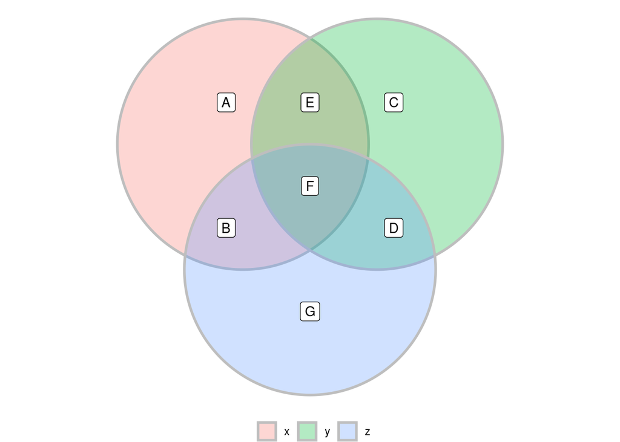

```r
tibble(x      = c(-0.8, 0.8,  0),
       y      = c(0.5,  0.5, -1),
       labels = c('x', 'y', 'z')) %>%
    ggplot() +
    geom_circle(aes(x0 = x, y0 = y, r = 1.5, fill = labels),
                alpha  = .3,
                size   = 1,
                colour = 'grey') +
    annotate(geom = "label", x = -1, y =  1,   label = "A") +
    annotate(geom = "label", x = -1, y = -0.5, label = "B") +
    annotate(geom = "label", x =  1, y =  1,   label = "C") +
    annotate(geom = "label", x =  1, y = -0.5, label = "D") +
    annotate(geom = "label", x =  0, y =  1,   label = "E") +
    annotate(geom = "label", x =  0, y =  0,   label = "F") +
    annotate(geom = "label", x =  0, y = -1.5,   label = "G") +
    labs(fill = "") +
    coord_fixed() +
    theme_void() +
    theme(legend.position = "bottom")
```

- If $x \in A$ then $xRx$ because $(x - x) \cup (x - x) = \emptyset$ where $\emptyset$ is finite. Why? In the definition of a finite set the antecedent of the conditional is false if $B = \emptyset$ so all the expression is true.
- If $x \in A \land x \in A \land xRy$. Therefore $(x - y) \cup (y - x)$ is finite. Also $(x - y) \cup (y - x) = (y - x) \cup (x -y)$. So $yRx$
- If $x \in A \land y \in A \land z \in A \land xRy \land yRz$ then $(x - y) \cup (y - x)$ and $(y - z) \cup (z - y)$ are finite. Furthermore $(x - y)$, $(y - x)$, $(y - z)$ and $(z - y)$ are also finite. We also have that
  - $(x - y)$ is the union of regions $A$ and $B$ in the plot. Therefore $A$ region is a finite set
  - $(y - x)$ is the union of regions $C$ and $D$ in the plot. Therefore $D$ region is a finite set
  - $(y - z)$ is the union of regions $E$ and $C$ in the plot. Therefore $E$ region is a finite set
  - $(z - y)$ is the union of regions $B$ and $G$ in the plot. Therefore $G$ region is a finite set
    - Because the union of $A$ and $E$ regions is equal to $(x - z)$ we have that $(x - z)$ is finite
    - Because the union of $D$ and $G$ regions is equal to $(z - x)$ we have that $(z - x)$ is finite
      - In that sense $(x - z) \cup (z - x)$ is finite. So $xRz$
        - $[x] = \{z: z \in \mathscr{P}(\mathbb{Z}) \land (x - z) \cup (z - x) \text{ is finite} \}$
          - If $x \subset \mathbb{Z}$, $x$ is finite and $xRz$ then $z$ must be finite. On the contrary, if $z$ is not finite $(z - x)$ will so $(x - z) \cup (z - x)$ will also not be finite and $\neg(xRz)$
          - If $x \subset \mathbb{Z}$, $x$ is not finite and $xRz$ then $x$ and $z$ must differ by only a finite number of elements. On the contrary, $(x - z) \cup (z - x)$ will not be finite and $\neg(xRz)$
            - For example for $e = \{x: x = 2n \land n \in \mathbb{Z} \}$ and $o = \{x: x = 2n + 1 \land n \in \mathbb{Z} \}$ we have that $\neg(eRo)$
            - For example for $\mathbb{Z}$ and $\mathbb{Z} - \{0 \}$ we have that $\mathbb{Z}R\mathbb{Z} - \{0 \}$
              - In that case we can take an $x$ that is not finite and begin to extract a finite number of elements from $x$ or add a finite number of elements not in $x$ to form sets that belong to $[x]$
  1. $A$ is the set of all integers and $R = \{(x,y): x \in A \land y \in A \land |x| = |y| \}$
     - If $x \in A$ then $xRx$ because $|x| = |x|$
     - If $x \in A \land xRy$ then $|x| = |y|$. Therefore $|y| = |x|$ and $yRx$
     - If $x \in A \land y \in A \land z \in A \land xRy \land yRz$ then $|x| = |y|$ and $|y| = |z|$. Therefore $|x| = |z|$ and $xRz$
       - $[x] = \{ x, -x \}$

## 1.34 Functions

A function is a binary relation $F$ such that:

$$(xFy \land xFz) \implies y = z$$
In other words, a binary relation $F$ is a function if and only if for all $x \in \mathscr{D}(F)$ there is exactly one $y$ such that $xFy$. This unique $y$ will be denoted as $F(x)$.

- $\begin{split} F \text{ is a function} & \iff F \text{ is a binary relation} \land (\forall x)(x \in \mathscr{D}(F) \implies (\exists !y)(xFy)) \\ & \iff F \text{ is a binary relation} \land (\forall x)(x \in \mathscr{D}(F) \implies F(x) = y) \end{split}$

## 1.35 Functions exercises and solutions

1. For each of the following relation $F$, determine whether it is a function. If it is, find its domain and if possible an explicit formula for $F(x)$
   1. Let $A$ be the set of real numbers and
      $$F = \{(x,y): x \in A \land y \in A \land x^2 + y^2 = 1 \}$$
      - $(0, 1) \in F \land (0, -1) \in F$. Therefore $F$ is not a function
   2. Let $A$ be the set of real numbers and
      $$F = \{(x,y): x \in A \land y \in A \land 2x + 3y = 12 \}$$
      - $\begin{split} 2x + 3y = 12 \land 2x + 3z = 12 & \implies 2x + 3y = 2x + 3z \\ & \implies 3y = 3z \\ & \implies y = z \end{split}$
      - $\begin{split} \mathscr{D}(F) & = \{ x: (\exists !y)(xFy) \} \\ & = \{ x: 2x + 3F(x) = 12 \land x \in \mathbb{R} \land F(x) \in \mathbb{R} \} \\ & = \{ x: F(x) = 4 - \frac{2x}{3} \land x \in \mathbb{R} \land F(x) \in \mathbb{R} \} \\ & = \mathbb{R} \end{split}$
      - $F(x) = 4 - \frac{2x}{3}$
   3. Same as b, except that $A$ is the set of positive integers
      - $\begin{split} F & = \{(x,y): x \in \mathbb{P} \land y \in \mathbb{P} \land 2x + 3y = 12 \} \\ & = \emptyset \end{split}$
        - $\emptyset \text{ is a function}$ is true because $(x, y) \in F \land (x, z) \in F$ is false so $(x, y) \in F \land (x, z) \in F \implies y = z$ is true
      - $\begin{split} \mathscr{D}(F) & = \{ x: (\exists !y)(xFy) \} \\ & = \{ x: 2x + 3F(x) = 12 \land x \in \mathbb{P} \land F(x) \in \mathbb{P} \} \\ & = \{ x: F(x) = 4 - \frac{2x}{3} \land x \in \mathbb{P} \land F(x) \in \mathbb{P} \} \\ & = \emptyset \end{split}$
   4. Let $A$ be the set of integers, and let
      $$F = \{(x,y): x \in A \land y \in A \land x^2 = y^2 \}$$
      - $(1, -1) \in F \land (1, 1) \in F$. Therefore $F$ is not a function
   5. Same as d, except that $A$ is the set of positive integers
      - $\begin{split} x^2 = y^2 \land x^2 = z^2 \land x > 0 & \implies |x| = |y| \land |x| = |z| \land x > 0 \land y > 0 \land z > 0 \\ & \implies x = y \land x = z \\ & \implies y = z \end{split}$
      - $\begin{split} \mathscr{D}(F) & = \{ x: (\exists !y)(xFy) \} \\ & = \{ x: x^2 = F(x)^2 \land x \in \mathbb{P} \land F(x) \in \mathbb{P} \} \\ & = \{ x: |x| = |F(x)| \land x \in \mathbb{P} \land F(x) \in \mathbb{P} \} \\ & = \{ x: x = F(x) \land x \in \mathbb{P} \land F(x) \in \mathbb{P} \} \\ & = \mathbb{P} \end{split}$
      - $F(x) = x$
   6. Let $A$ be the set of real numbers, and let
      $$F = \{(x,y): x \in A \land y \in A \land x + 1 > y - 2 \}$$
      - $(0, 1) \in F \land (0, -1) \in F$. Therefore $F$ is not a function
   7. Let $A$ be the set of real numbers, and let
      $$F = \{(x,y): x \in A \land y \in A \land x + y = y^2 \}$$
      - $(0, 0) \in F \land (0, 1) \in F$. Therefore $F$ is not a function
   8. Let $A$ be the set of people, and let
      $$F = \{(x,y): x \in A \land y \in A \land x \text{ is the mother of } y \}$$
      - $F$ is not a function because if $x$ isthe mother of $y$ and $y$ has a biological brother $z$ then $xFy \land xFz$ but $y \neq z$
   9. Let $A$ be the set of people, and let
      $$F = \{(x,y): x \in A \land y \in A \land \text{ is a daughter of } y \}$$
      - $F$ is a function if daughter doesn’t refer also to a stepdaughter. In that case daughter will mean biological daughter so a woman can’t have 2 biological mothers
      - $\begin{split} \mathscr{D}(F) & = \{ x: (\exists !y)(xFy) \} \\ & = \{ x: x \in A \land y \in A \land x \text{ is a daughter of } y \} \\ & = \{ x: x \text{ has a biological mother} \} \end{split}$
   10. Let $A$ be the set of real numbers, and let
       $$F = \{(x,y): x \in A \land y \in A \land x = y^2 + 1 \}$$
       - $(2, 1) \in F \land (2, -1) \in F$. Therefore $F$ is not a function
   11. Let $A$ be the set of real numbers, and let
       $$F = \{((x,y), z): x \in A \land y \in A \land z \in A \land x + y + z = 0 \}$$
       - $\begin{split} x + y + z_1 = 0 \land x + y + z_2 = 0 & \implies x + y + z_1 = x + y + z_2 \\ & \implies z_1 = z_2 \end{split}$
       - $\begin{split} \mathscr{D}(F) & = \{(x,y): (\exists !z)((x,y)Fz) \} \\ & = \{ (x,y): F((x,y)) = -x - y \land (x,z) \in \mathbb{R}^2 \land F((x,y)) \in R \} \\ & = \mathbb{R}^2 \end{split}$
       - $F((x,y)) = -x - y$
   12. Let $A$ be the set of real numbers, and let
       $$F = \{((x,y), z): x \in A \land y \in A \land z \in A \land x^2 + y^2 = z^2 \}$$
       - $((3, 4), 5) \in F \land ((3, 4), -5) \in F$. Therefore $F$ is not a function
   13. Same as l, except that $z \in A$ is replaced by $z \in A$ and $z \geq 0$
       - $\begin{split} x^2 + y^2 = z_1^2 \land x^2 + y^2 = z_2^2 \land z \geq 0 & \implies \sqrt{x^2 + y^2} = |z_1| \land \sqrt{x^2 + y^2} = |z_2| \land z \geq 0 \\ & \implies \sqrt{x^2 + y^2} = z_1 \land \sqrt{x^2 + y^2} = z_2 \\ & \implies z_1 = z_2 \end{split}$
       - $\begin{split} \mathscr{D}(F) & = \{(x,y): (\exists !z)((x,y)Fz) \} \\ & = \{ (x,y): F((x,y)) = \sqrt{x^2 + y^2} \land (x,z) \in \mathbb{R}^2 \land F((x,y)) \in R \land F((x,y) \geq 0 \} \\ & = \mathbb{R}^2 \end{split}$
       - $F((x,y)) = \sqrt{x^2 + y^2}$
   14. $F = \{ (1,1), (2,4), (4,16) \}$
       - $F$ is a function because if $(x, y) \in F \land (x, z) \in F \implies y = z$
       - $\begin{split} \mathscr{D}(F) & = \{x: (\exists !y)(xFy) \} \\ & = \{x: F(x) \in \{ 1, 4, 16 \} \} \\ & = \{ 1, 2, 4 \} \end{split}$
       - $F(x) = x^2$
   15. $F = \{ (0,3), (1,4), (2,6), (3,3) \}$
       - $F$ is a function because if $(x, y) \in F \land (x, z) \in F \implies y = z$
       - $\begin{split} \mathscr{D}(F) & = \{x: (\exists !y)(xFy) \} \\ & = \{x: F(x) \in \{ 3, 4, 6, 3 \} \} \\ & = \{ 0, 1, 2, 3 \} \end{split}$
   16. $F = \{ (0,3), (1,4), (2,6), (0,5) \}$
       - $(0, 3) \in F \land (0, 5) \in F$. Therefore $F$ is not a function
2. For each of the following formulas determining functions, find the domain which is implicitly assumed
   1. $F(x) = \sqrt{x + 2}$
      - $\begin{split} \mathscr{D}(F) & = \{x: x \geq 2 \land x \in \mathbb{R} \} \\ \end{split}$
   2. $F(x) = \sqrt{x^2 - 1}$
      - $\begin{split} \mathscr{D}(F) & = \{x: x \leq -1 \land x \geq 1 \land x \in \mathbb{R} \} \\ \end{split}$
   3. $F(x) = \text{the employer of x}$
      - $\begin{split} \mathscr{D}(F) & = \{x: x \text{ is a employee} \} \\ \end{split}$
   4. $F(x) = \text{the wife of x}$
      - $\begin{split} \mathscr{D}(F) & = \{x: x \text{ is a husband} \} \\ \end{split}$
   5. $F(x) = \sqrt{x + y} + 2$
      - $\begin{split} \mathscr{D}(F) & = \{(x,y): x + y \geq 0 \land x \in \mathbb{R} \land y \in \mathbb{R} \} \\ \end{split}$
   6. $F(x) = \sqrt{4 - x^2} + \sqrt{x^2 - 1}$
      - $\begin{split} \mathscr{D}(F) & = \{(x,y): x \leq - 2 \land -1 \leq x \leq 1 \land x \geq 2 \land x \in \mathbb{R} \} \\ \end{split}$
3. Consider any function $F$ and $G$. Prove that if
   - $F$ and $G$ have the same domain $A$
     - $\mathscr{D}(F) = \mathscr{D}(G)$
   - for any $x$ in $A$, $F(x) = G(x)$
     - $(\forall)(x \in \mathscr{D}(F) \implies F(x) = G(x))$

then $F = G$ (Hint: Show that $(x, y) \in F \iff (x, y) \in G$). This result provides the method by which we shall, in the course of the book, prove that two functions are equal.

- $\begin{split} (x,y) \in F & \iff xFy \\ & \iff x \in \mathscr{D}(F) \land F(x) = y \\ & \iff x \in \mathscr{D}(G) \land G(x) = y \\ & \iff xGy \\ & \iff (x,y) \in G \end{split}$
  - We conclude that $F \subseteq G \land G \subseteq F$ so $F = G$
4. Let $\mathscr{X}$ be any set of functions such that any two of them have disjoint domains, that is
   $$(\forall F)(\forall G)(F \in \mathscr{X} \land G \in \mathscr{X} \land F \neq G \implies \mathscr{D}(F) \cap \mathscr{D}(G) = \emptyset)$$
   Prove that $\bigcup_{F \in \mathscr{X}} F$ is a function and that it’s domain is the union of the domain s of the functions in $\mathscr{X}$
- $\begin{split} (x,y) \in \bigcup_{F \in \mathscr{X}} F \land (x,z) \in \bigcup_{F \in \mathscr{X}} F & \implies (\exists F_1)(xF_1y \land F_1 \in \mathscr{X}) \land (\exists F_2)(xF_2z \land F_2 \in \mathscr{X}) \\ & \implies (\exists F_1)(x \in \mathscr{D}(F_1) \land F_1(x) = y \land F_1 \in \mathscr{X}) \land (\exists F_2)(x \in \mathscr{D}(F_2) \land F_2(x) = z \land F_2 \in \mathscr{X}) \\ \end{split}$
  - If $F_1 \in \mathscr{X} \land F_2 \in \mathscr{X} \land F_1 \neq F_2$ then $\mathscr{D}(F_1) \cap \mathscr{D}(F_2) = \emptyset$. But $x \in \mathscr{D}(F_1) \land x \in \mathscr{D}(F_2)$ so $\mathscr{D}(F_1) \cap \mathscr{D}(F_2) \neq \emptyset$. Therefore $F_1 = F_2$ and $y = z$
- Because $\bigcup_{F \in \mathscr{X}} F$ is a function we have that:
  - $\begin{split} \mathscr{D}(\bigcup_{F \in \mathscr{X}} F) & = \{x: (\exists y)((x,y) \in \bigcup_{F \in \mathscr{X}} F) \} \\ & = \{x: (\exists y)(\exists !F)(F \in \mathscr{X} \land xFy \} \\ & = \{x: (\exists !F)(F \in \mathscr{X} \land (\exists y)(xFy) \} \\ & = \{x: (\exists !F)(F \in \mathscr{X} \land x \in \mathscr{D}(F) \} \\ & = \bigcup_{F \in \mathscr{X}} \mathscr{D}(F) \end{split}$

## 1.36 Functions from $A$ into (onto) $B$

$F: A \longrightarrow B$ means:

- $F$ is a function
- $\mathscr{D}(F) = A$
- $\mathscr{R}(F) \subseteq B$

If $F: A \to B$, we shall say that $F$ is a function from $A$ into $B$

If $F$ is a function from $A$ into $B$ and the range of $F$ is all of $B$, then we shall say that $F$ is a function from $A$ **onto** $B$. This will be written $F: A \xrightarrow[\text{onto}]{\text{}} B$. Thus

$$F: A \xrightarrow[\text{onto}]{\text{}} B \iff (F: A \longrightarrow B \land \mathscr{R}(F) = B)$$

## 1.37 Functions from $A$ into (onto) $B$ exercises and solutions

1. For each of the following functions $F$ and sets $A$ and $B$, determine whether $F$ is a function from $A$ **onto** $B$
   1. $A$ and $B$ are both the set of integers, $F(x) = -x$ for each integer $x$
      - $F: \mathbb{Z} \longrightarrow \mathbb{Z}$
      - $F = \{(x,y): x \in \mathbb{Z} \land y \in \mathbb{Z} \land F(x) = -x \}$
      - $\mathscr{R}(F) = \{y: (\exists x)(y = -x) \} \subseteq \mathbb{Z}$
        - Let $z \in \mathbb{Z}$ then $z \in \mathscr{R}(F)$ because $-z = x \in \mathbb{Z} \land y = -(-z) = z$
   2. Let $C$ be the set of nonnegative integers: $C = \mathbb{P} \cup \{ 0 \}$. Let $A = C \times C$ and let $B = C$. Let $F(x,y) = 2^x(2y + 1)$ for all $x$ and $y$ in $C$
      - $F: C^2 \longrightarrow C$
      - $F = \{((x,y),z): (x,y) \in C^2 \land z \in C \land F((x,y)) = 2^x(2y + 1) \}$
      - $\mathscr{R}(F) = \{z: (\exists (x,y))(z = 2^x(2y + 1)) \} \subseteq C$
        - $0 \in C$ but $0 \notin \mathscr{R}(F)$ because $2^x \geq 1$ and $2y + 1 \geq 1$ so $z = 2^x(2y + 1) \geq 1$
   3. $A$ and $B$ are both equal to the set of real numbers. $F(x) = 3x$ for all $x$ in $A$
      - $F: \mathbb{R} \longrightarrow \mathbb{R}$
      - $F = \{(x,y): x \in \mathbb{R} \land y \in \mathbb{R} \land F(x) = 3x \}$
      - $\mathscr{R}(F) = \{y: (\exists x)(y = 3x) \} \subseteq \mathbb{R}$
        - Let $z \in \mathbb{R}$ then $z \in \mathscr{R}(F)$ because $\frac{z}{3} = x \in \mathbb{R} \land y = z$
   4. $C$ and $D$ are arbitrary sets. Let $A = C \times D$ and $B = D \times C$. $F((x,y)) = (y, x)$ for all $(x, y)$ in $C \times D$
      - $F: C \times D \longrightarrow D \times C$
      - $F = \{(y,x): y \in D \land x \in C \land F((x,y)) = (y, x) \}$
      - $\mathscr{R}(F) = \{(y,x): (\exists (x,y))(F((x,y)) = (y, x)) \} \subseteq D \times C$
        - Let $(v, u) \in \subseteq D \times C$ then $(v, u) \in \mathscr{R}(F)$ because $(u, v) = (x, y) \in C \times D \land (y, x) = (v, u)$
   5. $A$ and $B$ are both equal to the set of real numbers. $F(x) = 2x + 1$ for all $x$ in $A$
      - $F: \mathbb{R} \longrightarrow \mathbb{R}$
      - $F = \{(x,y): x \in \mathbb{R} \land y \in \mathbb{R} \land F(x) = 2x + 1 \}$
      - $\mathscr{R}(F) = \{y: (\exists x)(y = 2x + 1) \} \subseteq \mathbb{R}$
        - Let $z \in \mathbb{R}$ then $z \in \mathscr{R}(F)$ because $\frac{z - 1}{2} = x \in \mathbb{R} \land y = z$
   6. Same as e, except that $A$ and $B$ are both equal to the set of integers.
      - $F: \mathbb{Z} \longrightarrow \mathbb{Z}$
      - $F = \{(x,y): x \in \mathbb{Z} \land y \in \mathbb{Z} \land F(x) = 2x + 1 \}$
      - $\mathscr{R}(F) = \{y: (\exists x)(y = 2x + 1) \} \subseteq \mathbb{Z}$
        - $2 \in \mathbb{Z}$ but $2 \notin \mathscr{R}(F)$ because $\frac{1}{2} = x \notin \mathbb{Z}$ so $y = 2x + 1 \neq 2$
   7. Same as e, except that $A$ and $B$ are both equal to the set of nonnegative real numbers.
      - $F: \mathbb{R}^+ \longrightarrow \mathbb{R}^+$
        - $\mathbb{R}^+ = \{ x: x \in \mathbb{R} \land x \geq 0 \}$
      - $F = \{(x,y): x \in \mathbb{R}^+ \land y \in \mathbb{R}^+ \land F(x) = 2x + 1 \}$
      - $\mathscr{R}(F) = \{y: (\exists x)(y = 2x + 1) \} \subseteq \mathbb{R}^+$
        - $\frac{1}{2} \in \mathbb{R}^+$ but $\frac{1}{2} \notin \mathscr{R}(F)$ because $-\frac{1}{4} = x \notin \mathbb{R}^+$ so $y = 2x + 1 \neq \frac{1}{2}$

## 1.38 One-one functions

A function $F$ is *one-one* (or 1-1) if and only if distinct objects $x$ and $y$ in the domain of $F$ implies $F(x) \neq F(y)$. Thus,

$$F \text{ is one-one} \iff (\forall x)(\forall y)((x \in \mathscr{D}(F) \land y \in \mathscr{D}(F) \land x \neq y) \implies F(x) \neq F(y))$$
The above condition is equivalent to

$$F \text{ is one-one} \iff (\forall x)(\forall y)(F(x) = F(y) \implies x = y)$$
If we assume that $x \in \mathscr{D}(F) \land y \in \mathscr{D}(F)$ is true.

We use $F: A \xrightarrow[\text{}]{\text{1-1}} B$ to signify that $F: A \longrightarrow B$ and $F$ is one-one

**Theorem** If $F$ is a one-one function then $F^{-1}$ is a function and specifically a one-one function

- $F^{-1}$ is a function
  - $\begin{split} (x, y) \in F^{-1} \land (x, z) \in F^{-1} & \iff (y, x) \in F \land (z, x) \in F \\ & \implies F(y) = x \land F(z) = x \\ & \implies F(y) = F(z) \\ & \implies y = z \end{split}$
- $F^{-1}$ is a one-one function
  - $\begin{split} F^{-1}(x) = F^{-1}(y) = z & \iff F^{-1}(x) = z \land F^{-1}(y) = z \\ & \iff (x, z) \in F^{-1} \land (x, z) \in F^{-1} \\ & \iff (z, x) \in F \land (z, y) \in F \\ & \implies x = y \end{split}$

If $G: C \xrightarrow[\text{}]{\text{1-1}} D$ and $G: C \xrightarrow[\text{onto}]{\text{}} D$ we write this condition as $G: C \xrightarrow[\text{onto}]{\text{1-1}} D$. Taking into account this observation notice that if $F: A \xrightarrow[\text{}]{\text{1-1}} B$ then $F^{-1}: \mathscr{R}(F) \xrightarrow[\text{onto}]{\text{1-1}} A$:

- $F: A \xrightarrow[\text{}]{\text{1-1}} B$:
  - $\mathscr{D}(F) = A \land \mathscr{R}(F) \subseteq B$
  - $\mathscr{D}(F^{-1}) = \mathscr{R}(F) \subseteq B \land \mathscr{R}(F^{-1}) = \mathscr{D}(F) = A$
    - $F^{-1}: \mathscr{R}(F) \xrightarrow[\text{}]{\text{1-1}} A$
      - Because $\mathscr{R}(F^{-1}) = A$ we have that $F^{-1}: \mathscr{R}(F) \xrightarrow[\text{onto}]{\text{1-1}} A$

When $F: A \xrightarrow[\text{onto}]{\text{1-1}} B$, we say that $F$ is a one-one correspondence between $A$ and $B$. If there is one-one correspondence between $A$ and $B$, then $A$ and $B$ are said to be **equinumerous**

## 1.39 One-one functions exercises and solutions

1. Determine whether each of the following functions $F$ is one-one. If it is one-one, describe $F^{-1}$ by a formula or otherwise and find the domain of $F^{-1}$
   1. $F(x) = |x|$ for all real numbers $x$
      - $F(-1) = F(1) = 1$ but $-1 \neq 1$
   2. $F(x) = x^2 - 1$ for all real numbers $x$
      - $F(-1) = F(1) = 0$ but $-1 \neq 1$
   3. $F(x) = 7x + 3$ for all real numbers $x$
      - $\begin{split} F(x) = F(y) & \implies 7x + 3 = 7y + 3 \\ & \implies x = y \end{split}$
      - $\begin{split} (x, y) \in F{-1} & \iff (y, x) \in F \\ & \iff x = 7y + 3 \\ & \iff \frac{x - 3}{7} = y \\ & \iff \frac{x - 3}{7} = F^{-1}(x) \end{split}$
   4. $F(x) = 7x + 3$ for all integers $x$
      - $\begin{split} F(x) = F(y) & \implies 7x + 3 = 7y + 3 \\ & \implies x = y \end{split}$
      - $\begin{split} (x, y) \in F{-1} & \iff (y, x) \in F \\ & \iff x = 7y + 3 \\ & \iff \frac{x - 3}{7} = y \\ & \iff \frac{x - 3}{7} = F^{-1}(x) \end{split}$
   5. $F(x)$ is the father of $x$, for all $x$ such that $x$ is an only child
      - $\begin{split} F(x) = F(y) & \implies x = y \end{split}$
      - $F^{-1}: x \text{ is the son of } y$
        - $F^{-1}: \mathscr{R}(F) \longrightarrow \mathscr{D}(F)$
          - $\mathscr{D}(F^{-1}) = \mathscr{R}(F) = \{x: x \text{ is an only child}\}$
          - $\mathscr{R}(F^{-1}) = \mathscr{D}(F) = \{y: y \text{ is a father} \}$
   6. $F((x,y)) = \sqrt{x^2 + y^2}$ for all real numbers $x$
      - $F((-1,-1)) = F((1,1)) = \sqrt{2}$ but $(-1,-1) \neq (1,1)$
   7. $F(x)$ is the height of $x$ in inches, for all people $x$
      - $F(x) = F(y)$ but it is not necessarily true that $x$ and $y$ are the same individual
        - It can be that $x \neq y$ and have the same height
   8. $F((x,y)) = x + y$ for all real numbers $x$ and $y$
      - $F((2,2)) = F((1,3)) = 4$ but $(2,2) \neq (1,3)$
   9. Consider an equivalence relation $R$ in a set $A$. Let $F(x) = [x]$ for all $x$ in $A$ (Remember that $[x]$ is the equivalence class of $x$, relative to $R$)
      - $F(x) = [x] = \{z: z \in A \land xRz \}$
        - $F$ is a function because $xF[x] \land xF[y] \implies [x] = [y]$
        - However, we can have $F[x] = F[y]$ but $x \neq y$ for some equivalence relations $R$ in a set $A$
          - For example, let $A = \mathbb{R}$ and $R = \{(x,y): x \in \mathbb{R} \land y \in \mathbb{R} \land |x| = |y|\}$
            - $[x] = [-x]$ so $F(x) = F(-x)$ but it is not true that $x = -x$ for any $x \in \mathbb{R}$
2. In each of the following cases, show that $A$ and $B$ are equinumerous
   1. $A$ is the set of all even integers and $B$ is the set of all odd integers
      - $A = \{x: x = 2n \land n \in \mathbb{Z} \}$ and $B = \{x: x = 2n + 1 \land n \in \mathbb{Z} \}$
      - $F = \{(x,y): x \in A \land y \in B \land y = x + 1\}$
        - Let $z \in B$ then $z \in \mathscr{R}(F)$ because $x = z - 1$ so $y = z$
        - $F(x) = F(z)$ then $x + 1 = z + 1$ so $x = z$
   2. $A$ is the set of all even integers and $B$ is the set of all all integers
      - $A = \{x: x = 2n \land n \in \mathbb{Z} \}$ and $B = \mathbb{Z}$
      - $F = \{(x,y): x \in A \land y \in B \land y = \frac{x}{2} \}$
        - Let $z \in B$ then $z \in \mathscr{R}(F)$ because $x = 2z$ so $y = z$
        - $F(x) = F(z)$ then $\frac{x}{2} = \frac{z}{2}$ so $x = z$
   3. $A$ is the set of all real numbers between 0 and 1 (incluiding 0 and 1) and $B$ is the set of all real numbers between 1 and 3 (incluiding 1 and 3)
      - $A = \{x: 0 \leq x \leq 1 \land x \in \mathbb{R} \}$ and $B = \{x: 1 \leq x \leq 3 \land x \in \mathbb{R} \}$
      - $F = \{(x,y): x \in A \land y \in B \land y = 2x + 1 \}$
        - Let $z \in B$ then $z \in \mathscr{R}(F)$ because $x = \frac{z - 1}{2}$ so $y = z$
        - $F(x) = F(z)$ then $2x + 1 = 2z + 1$ so $x = z$
          - In general if $A = \{x: a \leq x \leq b \land a \neq b \land x \in \mathbb{R} \}$ and $B = \{x: c \leq x \leq d \land c \neq d \land x \in \mathbb{R} \}$ then $F: A \longrightarrow B$ with $F(x) = \frac{d - c}{b - a}x + c$ is onto and one to one

## 1.40 Composition of functions

**Theorem** If $F$ and $G$ are functions then $F \circ G$ is a function

- $\begin{split} (x, y) \in F \circ G \land (x, z) \in F \circ G & \iff (\exists w_1)(xGw_1 \land w_1Fy) \land (\exists w_2)(xGw_2 \land w_2Fz) \\ & \implies w_1 = w_2 \land w_1Fy \land w_2Fz \\ & \implies y = z \end{split}$

Notice also that:

- $\begin{split} \mathscr{D}(F \circ G) & = \{x: (\exists y)(x(F \circ G)y) \} \\ & = \{x: (\exists y)(\exists z)(xGz \land zGy) \} \\ & = \{x: (\exists y)(\exists z)(G(x) = z \land F(z) = y) \} \\ & = \{x: (\exists y)(F(G(x)) = y) \} \\ \end{split}$
  - Therefore $x \in \mathscr{D}(F \circ G)$ if and only if $x \in \mathscr{D}(G) \land G(x) \in \mathscr{D}(F)$. Furthermore, because $x \in \mathscr{D}(G) \iff G(x) \in \mathscr{R}(G)$ and $G(x) \in \mathscr{D}(F)$ then $\mathscr{R}(G) = \mathscr{D}(F)$
    - In general, we can have $\mathscr{R}(G) \subseteq \mathscr{D}(F)$. There can be $w \in \mathscr{D}(F) \land w \notin \mathscr{R}(G)$ but $(F \circ G)$ defined
  - Also for any $(x, y) \in F$ because $(F \circ G)(x) = y$ we have that $(F \circ G)(x) = F(G(x))$

Thus, the value of $(F \circ G)(x)$ is obtained by first applying $G$ to $x$ and then applying $F$ to the result $G(x)$

**Theorem** Consider functions $G: A \longrightarrow B$ and $F: B \longrightarrow C$. Then, $F \circ G: A \longrightarrow C$

- If $G: A \longrightarrow B$ and $F: B \longrightarrow C$ are functions then $F \circ G$ is a function.
- Then we prove that $\mathscr{D}(F \circ G) = \mathscr{D}(G)$
  - $\begin{split} x \in \mathscr{D}(F \circ G) & \iff x \in \mathscr{D}(G) \land G(x) \in \mathscr{D}(F) \\ & \implies x \in \mathscr{D}(G) \end{split}$
  - $\begin{split} x \in \mathscr{D}(G) & \iff G(x) \in \mathscr{D}(G) \\ & \implies x \in \mathscr{D}(G) \land G(x) \in \mathscr{D}(G) \\ & \implies x \in \mathscr{D}(G) \land G(x) \in \mathscr{D}(F) \\ & \iff x \in \mathscr{D}(F \circ G) \end{split}$
    - $\mathscr{D}(F \circ G) \subseteq \mathscr{D}(G) \land \mathscr{D}(G) \subseteq \mathscr{D}(F \circ G)$ then $\mathscr{D}(F \circ G) = \mathscr{D}(G) = A$
- Finally we prove that $\mathscr{R}(F \circ G) \subseteq C$
  - $\begin{split} y \in \mathscr{R}(F \circ G) & \iff (\exists x)(F(G(x)) = y) \\ & \implies (\exists G(x))(F(G(x)) = y) \land G(x) \in \mathscr{D}(F)\\ & \implies y \in \mathscr{R}(F) \end{split}$
  - Therefore $\mathscr{R}(F \circ G) \subseteq \mathscr{R}(F)$
    - $\mathscr{R}(F \circ G) \subseteq \mathscr{R}(F) \land \mathscr{R}(F) \subseteq C$ then $\mathscr{R}(F \circ G) \subseteq C$

**Theorem** If $G: A \xrightarrow[\text{}]{\text{1-1}} B$ and $F: B \xrightarrow[\text{}]{\text{1-1}} C$, then $F \circ G: A \xrightarrow[\text{}]{\text{1-1}} C$

- $\begin{split} (F \circ G)(x) = (F \circ G)(y) & \implies F(G(x)) = F(G(y)) \\ & \implies G(x) = G(y) \\ & \implies x = y \end{split}$

**Theorem** If $G: A \xrightarrow[\text{onto}]{\text{}} B$ and $F: B \xrightarrow[\text{onto}]{\text{}} C$, then $F \circ G: A \xrightarrow[\text{onto}]{\text{}} C$

- Because $\mathscr{R}(F \circ G) \subseteq \mathscr{R}(F) = C$, $\mathscr{R}(G) = B = \mathscr{D}(F)$ so we need to prove that $\mathscr{R}(F) \subseteq \mathscr{R}(F \circ G)$
  - $\begin{split} y \in \mathscr{R}(F) & \iff (\exists z)(F(z) = y) \\ & \iff (\exists z)(F(z) = y) \land z \in \mathscr{D}(F) \\ & \iff (\exists z)(F(z) = y) \land G(x) = z \land z \in \mathscr{R}(G) \land z \in z \in \mathscr{D}(F) \\ & \iff (\exists z)(F(G(x)) = y) \land G(x) \in \mathscr{R}(G) \land G(x) \in \mathscr{D}(F) \\ & \iff (\exists z)(F(G(x)) = y) \land x \in \mathscr{D}(G) \land G(x) \in \mathscr{D}(F) \\ & \iff (\exists z)(F(G(x)) = y) \land x \in \mathscr{D}(F \circ G) \\ & \iff (\exists z)(F(G(x)) = y) \\ & \iff y \in \mathscr{R}(F \circ G) \end{split}$
    - Therefore $\mathscr{R}(F \circ G) = \mathscr{R}(F) = C$

Using the above two theorems we obtain the following:

**Corollary** If $G: A \xrightarrow[\text{onto}]{\text{1-1}} B$ and $F: B \xrightarrow[\text{onto}]{\text{1-1}} C$, then $F \circ G: A \xrightarrow[\text{onto}]{\text{1-1}} C$

## 1.41 Composition of functions exercises and solutions

1. Assume $F: A \longrightarrow B$, $F: B \longrightarrow C$ and $H: C \longrightarrow D$. Show that $H \circ (G \circ F) = (H \circ G) \circ F)$
- $\begin{split} (x, y) \in (H \circ (G \circ F)) & \iff (H \circ (G \circ F))(x) = y \\ & \iff H(G \circ F)(x)) = y \\ & \iff H(G(F(x))) = y \\ & \iff (H \circ G)(F(x)) = y \\ & \iff ((H \circ G) \circ F)(x) \\ & \iff (x, y) \in ((H \circ G) \circ F) \end{split}$
2. Assume $F: A \xrightarrow[\text{onto}]{\text{1-1}} B$. Prove:
   1. $F{-1} \circ F = I_A$
      - $\begin{split} F: A \xrightarrow[\text{onto}]{\text{1-1}} B & \implies F^{-1}: B \xrightarrow[\text{onto}]{\text{1-1}} A \\ & \implies F^{-1} \circ F: A \xrightarrow[\text{onto}]{\text{1-1}} A \\ & \implies \mathscr{D}(F^{-1} \circ F) = A \end{split}$
      - $\begin{split} (x,y) \in (F^{-1} \circ F) & \iff F^{-1}(F(x)) = y \land (\exists z)(F(x) = z) \\ & \iff F^{-1}(F(x)) = y \land (\exists z)((x,z) \in F) \\ & \iff F^{-1}(F(x)) = y \land (\exists z)((x,z) \in F \land (z,x) \in F^{-1}) \\ & \iff F^{-1}(F(x)) = y \land (x,x) \in (F^{-1} \circ F) \\ & \iff F^{-1}(F(x)) = y \land F^{-1}(F(x)) = x \\ & \implies y = x \\ & \implies (F^{-1} \circ F)(x) = x = I_A(x) \end{split}$
        - Therefore $(F^{-1} \circ F)(x) = I_A(x)$
   2. $F \circ F^{-1} = I_B$
      - $\begin{split} F: A \xrightarrow[\text{onto}]{\text{1-1}} B & \implies F^{-1}: B \xrightarrow[\text{onto}]{\text{1-1}} A \\ & \implies F \circ F{-1}: B \xrightarrow[\text{onto}]{\text{1-1}} B \\ & \implies \mathscr{D}(F \circ F{-1}) = B \end{split}$
      - $\begin{split} (x,y) \in (F^{-1} \circ F) & \iff F^{-1}(F(x)) = y \land (\exists z)(F(x) = z) \\ & \iff F^{-1}(F(x)) = y \land (\exists z)((x,z) \in F) \\ & \iff F^{-1}(F(x)) = y \land (\exists z)((x,z) \in F \land (z,x) \in F^{-1}) \\ & \iff F^{-1}(F(x)) = y \land (x,x) \in (F^{-1} \circ F) \\ & \iff F^{-1}(F(x)) = y \land F^{-1}(F(x)) = x \\ & \implies y = x \\ & \implies (F^{-1} \circ F)(x) = x = I_B(x) \end{split}$
        - Therefore $(F^{-1} \circ F)(x) = I_B(x)$
   3. $(F^{-1})^{-1} = F$
      - $\begin{split} (x,y) \in (F^{-1})^{-1} & \iff (y,x) \in F^{-1} \\ & \iff (x,y) \in F \end{split}$
3. For each of the following functions $F$ and $G$, determine the compositions $F \circ G$, $G \circ F$ and find their domains
   1. $F(x) = x + 5$ for all integers $x$ and $G(x) = x^3$ for all integers $x$
      - $(F \circ G)(x) = x^3 + 5$
        - $\mathscr{D}(F \circ G) = \mathscr{D}(F) = \mathbb{Z}$
      - $(G \circ F)(x) = (x + 5)^3$
        - $\mathscr{D}(G \circ F) = \mathscr{D}(G) = \mathbb{Z}$
   2. $F(x) = x^2$ for all real numbers $x$ and $G(x) = \sqrt{x}$ for all nonnegative real numbers $x$
      - $(F \circ G)(x) = (\sqrt{x})^2 = x$
        - $\mathscr{D}(F \circ G) = \mathscr{D}(G) = \mathbb{R}^+$
      - $(G \circ F)(x) = \sqrt{x^2} = |x|$
        - $\mathscr{D}(G \circ F) = \mathscr{D}(F) = \mathbb{R}$
   3. $F(x) = -x$ for all positive integers $x$ and $G(x) = \sqrt{x}$ for all positive integers $x$
      - $\sqrt{2} \in \mathscr{R}(G) \land \sqrt{2} \notin \mathscr{D}(F)$
        - Therefore $F \circ G$ isn’t defined because $\mathscr{R}(G) \nsubseteq \mathscr{D}(F) = \mathbb{P}$
      - $-2 \in \mathscr{R}(F) \land -2 \notin \mathscr{D}(G)$
        - Therefore $G \circ F$ isn’t defined because $\mathscr{R}(F) \nsubseteq \mathscr{D}(G) = \mathbb{P}$
   4. $F(x) = \frac{x}{2}$ for all integers $x$ and $G(x) = 6x$ for all positive integers
      - $(F \circ G)(x) = \frac{6x}{2} = 3x$
        - $\mathscr{D}(F \circ G) = \mathscr{D}(G) = \mathbb{P}$
      - $\frac{1}{2} \in \mathscr{R}(F) \land \frac{1}{2} \notin \mathscr{D}(G)$
        - Therefore $G \circ F$ isn’t defined because $\mathscr{R}(F) \nsubseteq \mathscr{D}(G) = \mathbb{P}$
   5. $F(x) = -x$ for all real numbers $x$ and $G(x) = |x|$ for all real numbers $x$
      - $(F \circ G)(x) = -|x|$
        - $\mathscr{D}(F \circ G) = \mathscr{D}(G) = \mathbb{R}$
      - $(G \circ F)(x) = \sqrt{x^2} = |-x|$
        - $\mathscr{D}(G \circ F) = \mathscr{D}(F) = \mathbb{R}$
   6. $F(x) = \frac{x}{x^2 + 1}$ for all real numbers $x$ and $G(x) = \frac{1}{x}$ for all nonzero real numbers $x$
      - $(F \circ G)(x) = \frac{\frac{1}{x}}{(\frac{1}{x})^2 + 1} = \frac{\frac{1}{x}}{\frac{1}{x^2} + 1}$
        - $\mathscr{D}(F \circ G) = \mathscr{D}(G) = \mathbb{R} - \{ 0 \}$
      - $0 \in \mathscr{R}(F) \land 0 \notin \mathscr{D}(G)$
        - Therefore $G \circ F$ isn’t defined because $\mathscr{R}(F) \nsubseteq \mathscr{D}(G) = \mathbb{P}$
4. Assume that $G: A \xrightarrow[\text{}]{\text{1-1}} B$ and $F: B \xrightarrow[\text{}]{\text{1-1}} C$. Prove that $(F \circ G)^{-1} = G^{-1} \circ F^{-1}$
- $\begin{split} (x, y) \in (F \circ G)^{-1} & \iff (y, x) \in (F \circ G) \\ & \iff (\exists z)((y,z) \in G \land (z,x) \in F) \\ & \iff (\exists z)((z,y) \in G^{-1} \land (x,z) \in F^{-1}) \\ & \iff (\exists z)((x,z) \in F^{-1} \land (z,y) \in G^{-1}) \\ & \iff (x, y) \in (G^{-1} \circ F^{-1}) \\ \end{split}$
  - Therefore $(F \circ G)^{-1} = G^{-1} \circ F^{-1}$
5. Assume $G: A \longrightarrow B$ and $F: B \longrightarrow C$
   1. If $F\circ G$ is one-one, prove that $G$ is one-one
      - $\begin{split} G(x) = G(y) & \implies F(G(x)) = F(G(y)) \\ & \implies (F\circ G)(x) = (F\circ G)(y) \\ & \implies x = y \end{split}$
   2. If $F \circ G: A \xrightarrow[\text{onto}]{\text{}} C$ prove that $F: B \xrightarrow[\text{onto}]{\text{}} C$
      - $C = \mathscr{R}(F \circ G) \land \mathscr{R}(F \circ G) \subseteq \mathscr{R}(F) \implies C \subseteq \mathscr{R}(F)$
      - $\mathscr{R}(F) \subseteq C$
        - Therefore $\mathscr{R}(F) = C$

## 1.42 Operations

Let $A$ be a set. By a **singulary operation on $A$** we mean a function $F$ from $A$ into $A$. Thus,

$$F \text{ is a singulary operation on } A \iff F: A \longrightarrow A$$
This means that the values of $F$ as well as its arguments must belong to $A$

Let $A$ be a set. By a **binary operation on $A$** we mean a function $F$ from $A \times A$ into $A$. Thus,
$$F \text{ is a binary operation on } A \iff F: A \times A \longrightarrow A$$

## 1.43 Operations exercises and solutions

1. If $F$ is a binary operation on $A$, and $C \subseteq A$, we say that $C$ is **closed** under $F$ if and only if $F(x,y) \in C$ whenever $x$ and $y$ are in $C$. In each of the following cases, determine whether $C$ is closed under $F$
   1. $F(x,y) = x - y$ for all integers $x$ and $y$
      - $C$ is the set of all integers
        - $F(x,y) = x - y \in \mathbb{Z}$ whenever $x \in \mathbb{Z} \land y \in \mathbb{Z}$
      - $C$ is the set of all nonnegative integers
        - $F((0,1)) = -1 \notin \mathbb{Z^+} \cup \{ 0 \}$ but $0 \in \mathbb{Z^+} \cup \{ 0 \} \land 1 \in \mathbb{Z^+} \cup \{ 0 \}$
      - $C$ is the set of all even integers
        - $even = \{e: e = 2n \land n \in \mathbb{Z} \}$
        - $F((e_1,e_2)) = 2n_1 - 2n_2 = 2(n_1 - n_2) \in e \text{ because } (n_1 - n_2) \in \mathbb{Z}$ where $e_1 \in e \land e_2 \in e$
      - $C$ is the set of all odd integers
        - $odd = \{o: o = 2n + 1 \land n \in \mathbb{Z} \}$
        - $F((o_1,o_2)) = 2n_1 + 1 - 2n_2 - 1 = 2(n_1 - n_2) \notin o \text{ because } 2(n_1 - n_2) \in e$ where $o_1 \in o \land o_2 \in o$
      - $C = \{ -1, 0, 1\}$
        - $F((1,-1)) = 2 \notin \{ -1, 0, 1\}$ but $1 \in \{ -1, 0, 1\} \land -1 \in \{ -1, 0, 1\}$
   2. $F(x,y) = x \times y$ for all real numbers $x$ and $y$
      - $C = \{ 0, 1\}$
        - $F(0,1) = F(1,0) = 0 \in \{ 0, 1\}$ where $0 \in \{ 0, 1\} \land 1 \in \{ 0, 1\}$
      - $C$ is the set of positive real numbers
        - $F(x,y) = x \times y \in \mathbb{R}^+ - \{ 0 \}$ because $x \times y > 0$ whenever $x \in \mathbb{R}^+ - \{ 0 \} \land y \in \mathbb{R}^+ - \{ 0 \}$
      - $C$ is the set of nonnegative real numbers
        - $F(x,y) = x \times y \in \mathbb{R}^+$ because $x \times y \geq 0$ whenever $x \in \mathbb{R}^+ \land y \in \mathbb{R}^+$
      - $C$ is the set of all negative real numbers
        - $F(-1,-1) = 1 \notin \mathbb{R}^- - \{ 0 \}$ where $-1 \in \mathbb{R}^- - \{ 0 \}$
      - $C$ is the set of all real numbers $x$ such that $-1 \leq x \leq 1$
        - Let $-1 \leq y \leq 1 \land y \in \mathbb{R}$ then:
          - If $1 \geq x \geq 0$ then $1 \leq -x \leq xy \leq x \leq 1$
          - If $0 \geq x \geq -1$ then $1 \geq -x \geq xy \geq x \geq -1$
            - $-1 \leq F(x,y) = x \times y \leq 1$ whenever $-1 \leq x \leq 1$ and $-1 \leq y \leq 1$
      - $C$ is the set of all integers
        - $F(x,y) = x \times y \in \mathbb{Z}$ whenever $x \in \mathbb{Z} \land y \in \mathbb{Z}$
      - $C$ is the set of all rational numbers
        - $\mathbb{Q} = \{q: q = \frac{a}{b} \text{ where } a \in \mathbb{Z} \land b \in \mathbb{Z} - \{ 0 \} \}$
          - If $q_1 \in \mathbb{Q} \land q_2 \in \mathbb{Q}$ then $q_1q_2 = \frac{a_1}{b_1}\frac{a_2}{b_2} = \frac{a_1a2}{b_1b_2} \in \mathbb{Q}$
            - $F(x,y) = x \times y \in \mathbb{Q}$ whenever $x \in \mathbb{Q} \land y \in \mathbb{Q}$
      - $C$ is the set of all rational numbers of the form $\frac{k}{2^n}$ where $k$ and $n$ are integers
        - Let $q_1 = \frac{k_1}{2^{n_1}}$ and $q_2 = \frac{k_2}{2^{n_2}}$ then $q_1q_2 = \frac{k_1}{2^{n_1}}\frac{k_2}{2^{n_2}} = \frac{k_1k_2}{2^{n_1 + n_2}}$ where $k_1k_2 \in \mathbb{Z} \ land (n_1 + n_2) \in \mathbb{Z}$
          - $F(x,y) = x \times y \in \widehat{\mathbb{Q}} = \{ \widehat{q}: q = \frac{k}{2^n} \land k \in \mathbb{Z} \land n \in \mathbb{Z} \}$ whenever $x \in \widehat{\mathbb{Q}} \land y \in \widehat{\mathbb{Q}}$
      - $C$ is the set of all real numbers of the form $a + b\sqrt{2}$, where $a$ and $b$ are integers
        - Let $a_1 + b_1\sqrt{2}$ and $a_2 + b_2\sqrt{2}$ with $a_1, a_2, b_1$ and $b_2$ belong to $\mathbb{Z}$ then:
          - $\begin{split} (a_1 + b_1\sqrt{2})(a_2 + b_2\sqrt{2}) & = a_1a_2 + a_1b_2\sqrt{2} + a_2b_1\sqrt{2} + 2b_1b_2 \\ & = (a_1a_2 + 2b_1b_2) + (a_1b_2 + a_2b_1)\sqrt{2} \text{ where } (a_1a_2 + 2b_1b_2) \in \mathbb{Z} \land (a_1b_2 + a_2b_1) \in \mathbb{Z} \end{split}$
            - $F(x,y) = x \times y \in C$ whenever $x \in C \land y \in C$
2. In each of the following cases, determine whether the given function $F$ is a singulary or binary operation on the given set $A$
   1. $F(x)$ is the spouse of $x$, for all $x$ in the set $A$ of married people
      - $F: A \longrightarrow A$ therefore is a singulary operation
   2. $F(x)$ is the father of $x$, for all $x$ in the set $A$ of people
      - $F: A \longrightarrow A$ therefore is a singulary operation
   3. $F(x) = \frac{1}{x}$ for all $x$ in the set $A$ of nonzero integers
      - $F: A \longrightarrow \mathbb{Q}$ therefore is not a singulary or binary operation
        - $\frac{1}{x} \not in A$ if $x \neq 1$
   4. $F((x,y)) = x + y - 1$ for all $x$ and $y$in the set $A$ of positive integers
      - $F: A \times A \longrightarrow A$ therefore is a binary operation
   5. $F((x,y)) = (x \times y) - (x + y)$ for all integers $x$ and $y$ such that $x \geq 2$ and $y \geq 2$. Also $A = \{x: x \in \mathbb{Z} \land x \geq 2 \}$
      - $F: A \times A \longrightarrow \mathbb{Z}$ therefore is not a singulary or binary operation
        - $F((2,2)) = (2 \times 2) - (2 + 2) = 0 \notin A$
   6. $F((x,y)) = (x \times y) - (x + y)$ for all $x$ and $y$ in the set $A$ of integers
      - $F: A \times A \longrightarrow A$ therefore is a binary operation
   7. $F((x,y)) = x \times y$ for all $x$ and $y$ in the set $A = \{a + b\sqrt{3}: a \text{ and } b \text{ are rational numbers}\}$
      - Let $(a_1 + b_1\sqrt{3})(a_2 + b_2\sqrt{3})$ where $a_1 + b_1\sqrt{3} \in A$ and $a_2 + b_2\sqrt{3} \in A$ then:
        - $\begin{split} (a_1 + b_1\sqrt{3})(a_2 + b_2\sqrt{3}) & = a_1a_2 + a_1b_2\sqrt{3} + a_2b_1\sqrt{3} + 3b_1b_2 \\ & = (a_1a_2 + 3b_1b_2) + (a_1b_2 + a_2b_1)\sqrt{3} \text{ where } (a_1a_2 + 3b_1b_2) \in \mathbb{Q} \land (a_1b_2 + a_2b_1) \in \mathbb{Q} \end{split}$
   8. $F((x,y)) = \frac{x}{y}$ for all $x$ and $y$ in the set $A = \{a + b\sqrt{2}: a \text{ and } b \text{ are integers which are not both } 0\}$
      - Let $\frac{a_1 + b_1\sqrt{2}}{a_2 + b_2\sqrt{2}}$ where $a_1 + b_1\sqrt{2} \in A$ and $a_2 + b_2\sqrt{2} \in A$
        - $\frac{a_1 + b_1\sqrt{2}}{a_2 + b_2\sqrt{2}} = \frac{a_1}{a_2 + b_2\sqrt{2}} + \frac{b_1}{a_2 + b_2\sqrt{2}}\sqrt{2}$ where $\frac{a_1}{a_2 + b_2\sqrt{2}} \notin \mathbb{Z}$ and $\frac{b_1}{a_2 + b_2\sqrt{2}} \notin \mathbb{Z}$
          - Therefore $F((x,y)) = \frac{x}{y} \notin A$ so it is not a singulary or binary operation
   9. Same as h, except that $a$ and $b$ are rational numbers insted of integers
      - Let $\frac{a_1 + b_1\sqrt{2}}{a_2 + b_2\sqrt{2}}$ where $a_1 + b_1\sqrt{2} \in A$ and $a_2 + b_2\sqrt{2} \in A$
        - $\frac{a_1 + b_1\sqrt{2}}{a_2 + b_2\sqrt{2}} = \frac{a_1}{a_2 + b_2\sqrt{2}} + \frac{b_1}{a_2 + b_2\sqrt{2}}\sqrt{2}$ where $\frac{a_1}{a_2 + b_2\sqrt{2}} \notin \mathbb{Q}$ and $\frac{b_1}{a_2 + b_2\sqrt{2}} \notin \mathbb{Q}$
          - Therefore $F((x,y)) = \frac{x}{y} \notin A$ so it is not a singulary or binary operation
3. Consider a binary operation $F$ on a set $A$
   $$F: A \times A \longrightarrow A$$
   Assume $C \subseteq A$. By the **restriction of the operation $F$ to $C$**, we mean the function $G$ such that $\mathscr{D}(G) = C \times C$ and $G(x,y) = F(x,y)$ for all $x$ and $y$ in $C$
   1. Prove that the restriction $G$ of $F$ to $C$ is a binary operation on $C$ if and only if $C$ is closed under $F$
      - $\begin{split} F: A \times A \longrightarrow A \land C \subseteq A \land C \text{ is closed under } F & \iff F: A \times A \longrightarrow A \land C \subseteq A \land (\forall x)(\forall y)(x \in C \land y \in C \implies F((x,y)) \in C) \\ & \iff F: A \times A \longrightarrow A \land C \subseteq A \land (\forall x)(\forall y)((x,y) \in C \times C \implies F((x,y)) \in C) \\ & \iff F: A \times A \longrightarrow A \land C \subseteq A \land (\exists G)( G \text{ is a function } \land \mathscr{D}(G) = C \times C \land (\forall x)(\forall y)(x \in C \land y \in C \implies G(x,y) = F(x,y))) \\ & \iff F: A \times A \longrightarrow A \land C \subseteq A \land G \text{ is a restriction of the operation } F \text{ to } C \end{split}$
   2. Let $F(x,y) = (x \times y) - |x||y|$ for all real numbers $x$ and $y$. $F$ is a binary operation on the set of real numbers. What is the restriction of $F$ to the set of nonnegative real numbers?
      - $F: \mathbb{R}^2 \longrightarrow \mathbb{R}$
      - $\mathbb{R}^+ \subseteq \mathbb{R}$
        - $G$ is a function
        - $\mathscr{D}(G) = \mathbb{R}^+ \times \mathbb{R}^+$
        - $G(x,y) = F(x,y) = (x \times y) - |x||y|$
          - Possible $G$s:
            - $G: \mathbb{R}^+ \times \mathbb{R}^+ \xrightarrow[\text{onto}]{\text{}} \{ 0 \}$
            - $G: \mathbb{R}^+ \times \mathbb{R}^+ \longrightarrow \mathbb{R}^+$
            - $G: \mathbb{R}^+ \times \mathbb{R}^+ \longrightarrow \mathbb{R}$

# Bibliography

Bilaniuk, Stefan. 2009. *A Problem Course in Mathematical Logic*. http://euclid.trentu.ca/math/sb/pcml/pcml.html.

Halmos, Paul R. 1974. *Naive Set Theory*. Edited by S. Axler, F. W. Gehring, and K. A. Ribet. Undergraduate Texts in Mathematics. New York, NY: Springer New York. https://doi.org/10.1007/978-1-4757-1645-0.

Jech, Thomas. 2003. *Set Theory*. Springer Monographs in Mathematics. Berlin, Heidelberg: Springer Berlin Heidelberg. https://doi.org/10.1007/3-540-44761-X.

Mendelson, Elliott. 2008. *Number Systems and the Foundations of Analysis*. Mineola, N.Y: Dover Publications.

Smullyan, Raymond M. 2014. *A Beginner’s Guide to Mathematical Logic*. Dover Books on Mathematics. Mineola, New York: Dover Publications, Inc.

[^1]: This is a rule of inference and it is know as **conjunction elimination**